# Analyses of GSE138988

## GSEA Length

Now that we have our genes of interest, it would also be interesting to see what are the **altered pathways** between enriched and depleted RNAs from the stress granules. Therefore, lets perform a *Gene Set Enrichment Analysis*

```r
#for all genes
DEGenes.stress <- DEGenes.stress[order(DEGenes.stress[,8]),]
gseatool <- DEGenes.stress[,8]
gseatool <- as.data.frame(gseatool)
colnames(gseatool)[1] <- "t"
gseatool[,2] <- DEGenes.stress$Gene
colnames(gseatool)[2] <- "Symbol"
gseatool <- gseatool[,c(2,1)]


vectorranks <- log10(gseatool$t)
vectorranks <- scale(vectorranks)
names(vectorranks) <- gseatool$Symbol


#to load our pathways

##-----HALLMARK-----
hallmarks.gs <- msigdbr(species = "Homo sapiens", collection = "H")

hallmarks.gsets <- hallmarks.gs %>% split(x = .$gene_symbol, f = .$gs_name)

for (set in names(hallmarks.gsets)){
  hallmarks.gsets[[set]] <- toupper(hallmarks.gsets[[set]])
}

hallmarks.res <- fgsea(pathways = hallmarks.gsets,
                       stats = vectorranks)
```

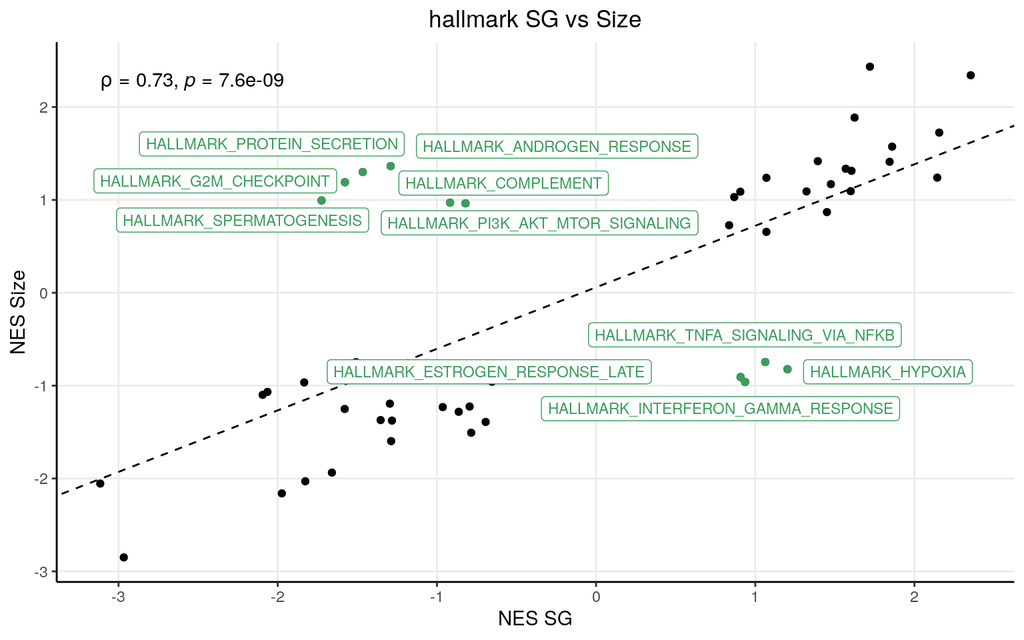

```r
hallmarks.res.tidy <- hallmarks.res %>%
  as_tibble() %>%
  arrange(desc(NES))

hallmarks.res.tidy %>%
  dplyr::select(-leadingEdge, -ES) %>%
  arrange(padj)

hallmark.size.t <- hallmarks.res.tidy[,c(1,6)]
hallmark.size.t <- as.data.frame(hallmark.size.t)

#HALLMARK
hallmark.scatter_ak <- merge(hallmark.sg.t, hallmark.size.t, by="pathway")
colnames(hallmark.scatter_ak) <- c("pathway", "sg", "size")
hallmark.scatter_ak <- na.omit(hallmark.scatter_ak)
res_hallmark <- lm(size ~ sg, hallmark.scatter_ak)

vip.pathways_ak <- as.data.frame(hallmark.scatter_ak[(hallmark.scatter_ak$sg/hallmark.scatter_ak$size)<0,] )



ggplot(hallmark.scatter_ak, aes(x=sg, y=size)) + geom_point(color="black", alpha=01) +   theme_bw()+
 xlab("NES SG") + ylab("NES Size") +
  theme(axis.line = element_line(colour = "black"),
        panel.grid.minor = element_blank(),
        panel.border = element_blank(),
        panel.background = element_blank()) + ggtitle("hallmark SG vs Size")+
  theme(plot.title = element_text(hjust = 0.5)) +
  geom_abline(slope=res_hallmark$coefficients[2], intercept = res_hallmark$coefficients[1], linetype = "dashed") +
  geom_label_repel(vip.pathways_ak[1:ndegs,] , mapping=aes(label=vip.pathways_ak$pathway[1:ndegs]),size=3,point.padding=-0.5, color="#399e5a",max.overlaps = 200)+
  geom_point(data=vip.pathways_ak, aes(x=sg, y= size), color="#399e5a") + stat_cor(method = "spearman", cor.coef.name = "rho")
```

# More Complex Linear Models

Finally, we move on to differential gene expression! In this chunk, I define the linear model I will actually use for my analyses. In this case, since I have 4 comparisons I want to check, I will have 4 contrast matrixes.

```r
#I start with the simplest analysis possible
mm <- model.matrix(~0+forsamp*forstress)

fitted <- lmFit(y, mm)

head(coef(fitted))
```

```
##          forsampBulk forsampSG  forstressS forsampSG:forstressS
## 7SK        13.159437 11.209618  0.63840161            0.3507537
## A1BG        2.590825  1.834602 -0.24365808            0.6729237
## A1BG-AS1    2.972066  3.240622 -0.12095475            0.5009668
## A2M         3.722897  4.982433 -0.85907951           -0.6732472
## AAAS        5.207613  6.194237 -0.05451936           -0.9610180
## AACS        5.116202  6.036430  0.15381764           -0.5718529
```

```r
#next we measure contrasts between groups (log-fold change is obtained from these fitted linear models)
colnames(fitted$coefficients) <- make.names(colnames(fitted$coefficients))
contr.sgvsbu <- makeContrasts(forsampSG - forsampBulk, levels = colnames(coef(fitted)))

#next we estimate the contrast for each gene
tmp.sgvsbu <- contrasts.fit(fitted, contr.sgvsbu)

#use empirical bayes smoothing of standard erros (shrinks extreme standard erros)
tmp.sgvsbu <- eBayes(tmp.sgvsbu)
tmp <- eBayes(fitted)

top.table.sgvsbu <- topTable(tmp.sgvsbu, sort.by = "logFC", n = Inf)
top.table.uvss <- topTable(tmp,3, sort.by = "logFC", n = Inf)
top.table.int <- topTable(tmp, 4, sort.by = "logFC", n = Inf)

DEGenes.sgvsbu <- top.table.sgvsbu
DEGenes.uvss <- top.table.uvss
DEGenes.int <- top.table.int
```

# SG vs Bulk

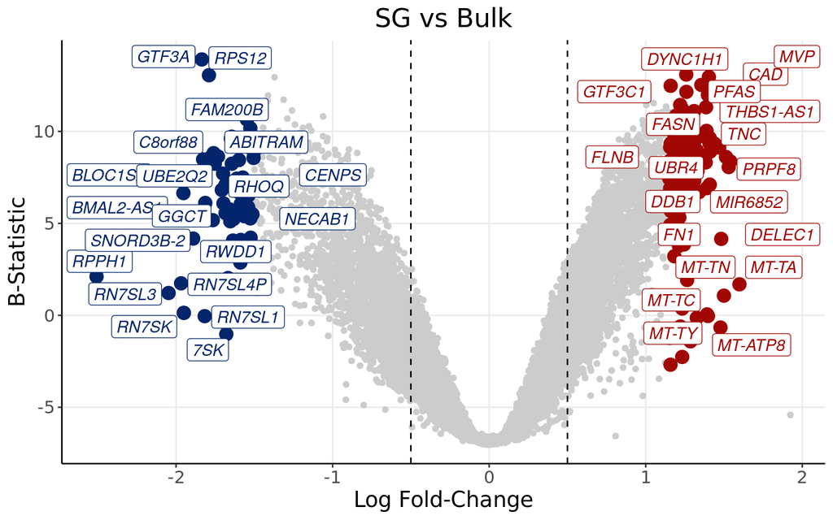

```r
upmarkers <- as.data.frame(DEGenes.sgvsbu[DEGenes.sgvsbu$logFC>1.15 & DEGenes.sgvsbu$adj.P.Val<0.05,] )
downmarkers <- as.data.frame(DEGenes.sgvsbu[DEGenes.sgvsbu$logFC< -1.5 & DEGenes.sgvsbu$adj.P.Val<0.05,] )

ggplot(data=DEGenes.sgvsbu,
                 aes(x=logFC,
                     y=  B)) +
  geom_point(color="#CCCCCC")+ geom_vline(xintercept = -0.5, linetype="dashed")+geom_vline(xintercept = 0.5, linetype="dashed")+
  theme_bw() + ylab("B-Statistic")+xlab("Log Fold-Change")+
  theme(axis.line = element_line(colour = "black"),
        panel.grid.minor = element_blank(),
        panel.border = element_blank(),
        panel.background = element_blank()) +
  ggtitle("SG vs Bulk")+
  theme(plot.title = element_text(hjust = 0.5), plot.subtitle = element_text(hjust = 0.5)) +
  geom_point(data=upmarkers, aes(x=logFC, y=  B), color="#A10702",size=4)+
  geom_point(data=downmarkers, aes(x=logFC, y=  B), color="#03256C",size=4)+
  geom_label_repel(upmarkers[1:ndegs,] , mapping=aes(label=row.names(upmarkers)[1:ndegs]),size=4,point.padding=-0.5, color="#A10702",max.overlaps = 20, fontface="italic")+
  geom_label_repel(downmarkers[1:ndegs,] , mapping=aes(label=row.names(downmarkers)[1:ndegs]),size=4,point.padding=-0.5, color="#03256C",max.overlaps = 20, fontface="italic")+
  theme(text=element_text(size=15,  family="Arial MS"))
```

## SG vs Bulk (Volcano Plot with Gene Length)

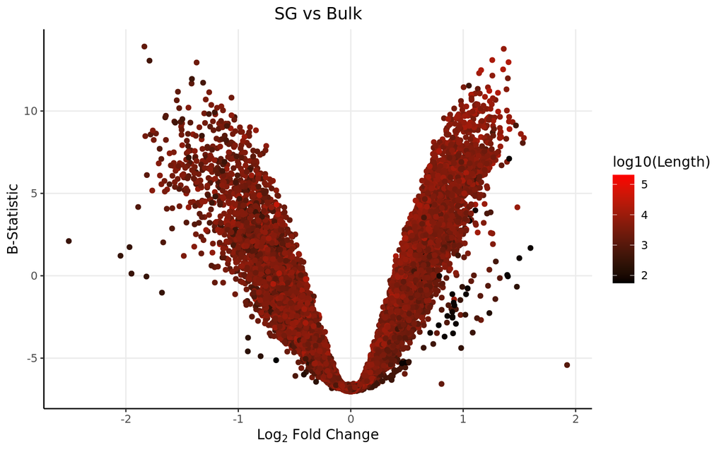

```r
DEGenes.sgvsbu$Gene <- row.names(DEGenes.sgvsbu)
colnames(genelength) <- c("Length","Gene")
DEGenes.sgvsbu <- merge(DEGenes.sgvsbu, genelength, by="Gene")

ggplot(data=DEGenes.sgvsbu,
                 aes(x=logFC,
                     y=  B)) +
  geom_point(aes(color=log10(Length)))+
  theme_bw() +
  theme(axis.line = element_line(colour = "black"),
        panel.grid.minor = element_blank(),
        panel.border = element_blank(),
        panel.background = element_blank()) +
  ggtitle("SG vs Bulk")+ xlab(expression(Log[2] ~ Fold ~ Change)) + ylab("B-Statistic") +
  theme(plot.title = element_text(hjust = 0.5))  +
  scale_colour_gradient(low = "black", high = "red")+ theme(text=element_text(family = "Quicksand"))
```

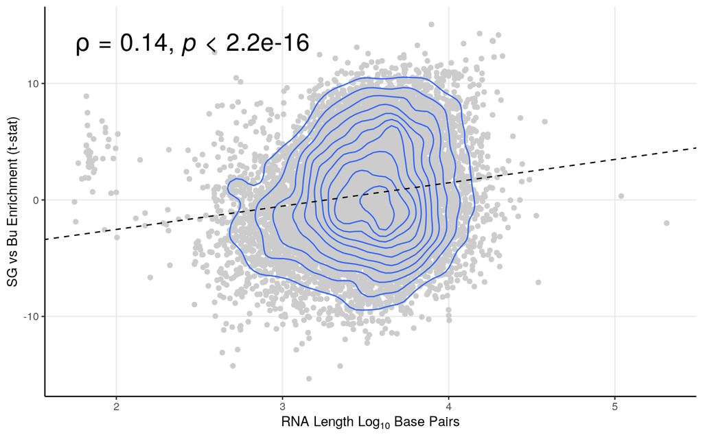

```r
smooth.SG <- lm(t~log10(Length), DEGenes.sgvsbu)
liner.SG <- rstandard(smooth.SG)
DEGenes.sgvsbu <-cbind(DEGenes.sgvsbu, liner.SG)
colnames(DEGenes.sgvsbu)[9] <- "Residuals"
row.names(DEGenes.sgvsbu) <- DEGenes.sgvsbu$Gene
linemarkers <- as.data.frame(DEGenes.sgvsbu[abs(DEGenes.sgvsbu$Residuals)>4,])

# Calculate the Spearman correlation coefficient
spearman_corr <- cor(DEGenes.sgvsbu$t, log10(DEGenes.sgvsbu$Length), method = "spearman")

ggplot(DEGenes.sgvsbu, aes(y=t, x=log10(Length))) + geom_point(color="#CCCCCC", alpha=1) +   theme_bw()+ geom_density_2d()+
 ylab("SG vs Bu Enrichment (t-stat)") + xlab(expression(RNA ~ Length ~ Log[10] ~ Base ~ Pairs)) +
  theme(axis.line = element_line(colour = "black"),
        panel.grid.minor = element_blank(),
        panel.border = element_blank(),
        panel.background = element_blank()) +
  theme(plot.title = element_text(hjust = 0.5))  +
  geom_abline(slope=smooth.SG$coefficients[2], intercept = smooth.SG$coefficients[1], linetype = "dashed")+ stat_cor(method = "spearman", cor.coef.name = "rho",size=7)
```

## GSEA

Now that we have our genes of interest, it would also be interesting to see what are the **altered pathways** between enriched and depleted RNAs from the stress granules. Therefore, lets perform a *Gene Set Enrichment Analysis*

```r
#for all genes
DEGenes.sgvsbu <- DEGenes.sgvsbu[order(DEGenes.sgvsbu[,4]),]
gseatool <- DEGenes.sgvsbu[,4]
gseatool <- as.data.frame(gseatool)
colnames(gseatool)[1] <- "t"
gseatool[,2] <- DEGenes.sgvsbu$Gene
colnames(gseatool)[2] <- "Symbol"
gseatool <- gseatool[,c(2,1)]

vectorranks <- gseatool$t
names(vectorranks) <- gseatool$Symbol


#to load our pathways
hallmarks.gs <- msigdbr(species = "Homo sapiens", collection =  "H")

hallmarks.gsets <- hallmarks.gs %>% split(x = .$gene_symbol, f = .$gs_name)

for (set in names(hallmarks.gsets)){
  hallmarks.gsets[[set]] <- toupper(hallmarks.gsets[[set]])
}

hallmarks.res <- fgsea(pathways = hallmarks.gsets,
                       stats = vectorranks)
```

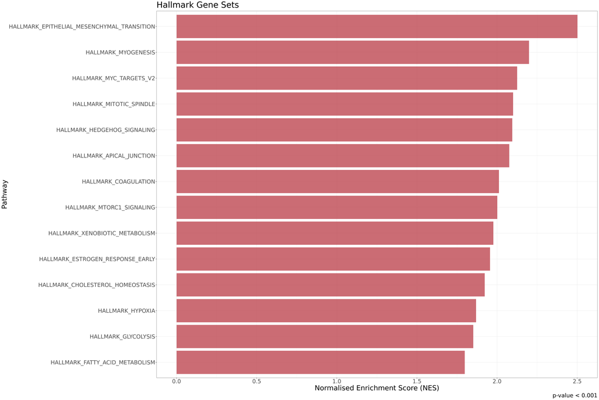

```r
hallmarks.res.tidy <- hallmarks.res %>%
  as_tibble() %>%
  arrange(desc(NES))

hallmarks.res.tidy %>%
  dplyr::select(-leadingEdge, -ES) %>%
  arrange(padj)

hallmark.sg.t <- hallmarks.res.tidy[,c(1,6)]
hallmark.sg.t <- as.data.frame(hallmark.sg.t)

#this small part is generic
thresh <- 0.001

#this one is no longer generic
data_to_plot <- hallmarks.res.tidy %>% filter(padj < thresh)

statvec <- c()
for (i in 1:nrow(data_to_plot)){
  if (data_to_plot[i,6] > 0){
    status <- "Upregulated"
  }
 else {
   status <- "Downregulated"
 }
statvec <- c(statvec, status)
}

data_to_plot$Status <- statvec

##-----HALMARK-----
gsea_plot_hall <- ggplot(data_to_plot, aes(reorder(pathway, NES), NES)) +
  geom_col(aes(fill= Status), alpha=0.75) + scale_fill_manual(values = c("#53A2BE","#BA3B46"), name = "Regulation Status", labels = c("Downregulated", "Upregulated"), breaks = c("Downregulated", "Upregulated")) +
  coord_flip() +
  labs(x="Pathway", y="Normalised Enrichment Score (NES)",
       title= "Hallmark Gene Sets",
       caption = paste0("p-value < ", thresh)) + theme(plot.title = element_text(hjust = 1)) +
  theme_bw() + theme(text=element_text(family = "Quicksand")) + theme(legend.position = "none")

gsea_plot_hall+
  theme(text=element_text(size=25,  family="Arial MS"))
```

## GSEA Length

Now that we have our genes of interest, it would also be interesting to see what are the **altered pathways** between enriched and depleted RNAs from the stress granules. Therefore, lets perform a *Gene Set Enrichment Analysis*

```r
#for all genes
DEGenes.sgvsbu <- DEGenes.sgvsbu[order(DEGenes.sgvsbu[,8]),]
gseatool <- DEGenes.sgvsbu[,8]
gseatool <- as.data.frame(gseatool)
colnames(gseatool)[1] <- "t"
gseatool[,2] <- DEGenes.sgvsbu$Gene
colnames(gseatool)[2] <- "Symbol"
gseatool <- gseatool[,c(2,1)]


vectorranks <- log10(gseatool$t)
vectorranks <- scale(vectorranks)
names(vectorranks) <- gseatool$Symbol


#to load our pathways

##-----HALLMARK-----
hallmarks.gs <- msigdbr(species = "Homo sapiens", collection = "H")

hallmarks.gsets <- hallmarks.gs %>% split(x = .$gene_symbol, f = .$gs_name)

for (set in names(hallmarks.gsets)){
  hallmarks.gsets[[set]] <- toupper(hallmarks.gsets[[set]])
}

hallmarks.res <- fgsea(pathways = hallmarks.gsets,
                       stats = vectorranks)
```

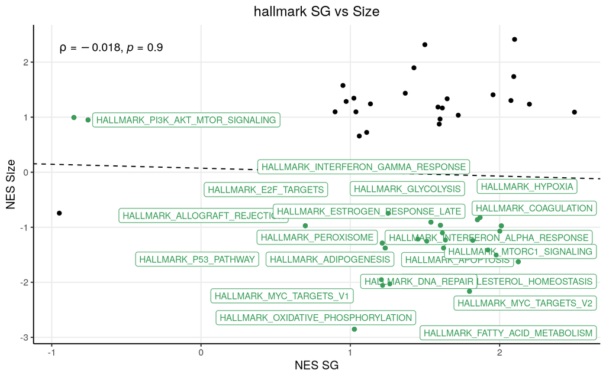

```r
hallmarks.res.tidy <- hallmarks.res %>%
  as_tibble() %>%
  arrange(desc(NES))

hallmarks.res.tidy %>%
  dplyr::select(-leadingEdge, -ES) %>%
  arrange(padj)

hallmark.size.t <- hallmarks.res.tidy[,c(1,6)]
hallmark.size.t <- as.data.frame(hallmark.size.t)

#HALLMARK
hallmark.scatter_ak <- merge(hallmark.sg.t, hallmark.size.t, by="pathway")
colnames(hallmark.scatter_ak) <- c("pathway", "sg", "size")
hallmark.scatter_ak <- na.omit(hallmark.scatter_ak)
res_hallmark <- lm(size ~ sg, hallmark.scatter_ak)

vip.pathways_ak <- as.data.frame(hallmark.scatter_ak[(hallmark.scatter_ak$sg/hallmark.scatter_ak$size)<0,] )



ggplot(hallmark.scatter_ak, aes(x=sg, y=size)) + geom_point(color="black", alpha=01) +   theme_bw()+
 xlab("NES SG") + ylab("NES Size") +
  theme(axis.line = element_line(colour = "black"),
        panel.grid.minor = element_blank(),
        panel.border = element_blank(),
        panel.background = element_blank()) + ggtitle("hallmark SG vs Size")+
  theme(plot.title = element_text(hjust = 0.5)) +
  geom_abline(slope=res_hallmark$coefficients[2], intercept = res_hallmark$coefficients[1], linetype = "dashed") +
  geom_label_repel(vip.pathways_ak[1:ndegs,] , mapping=aes(label=vip.pathways_ak$pathway[1:ndegs]),size=3,point.padding=-0.5, color="#399e5a",max.overlaps = 200)+
  geom_point(data=vip.pathways_ak, aes(x=sg, y= size), color="#399e5a") + stat_cor(method = "spearman", cor.coef.name = "rho")
```

# Stress vs Control

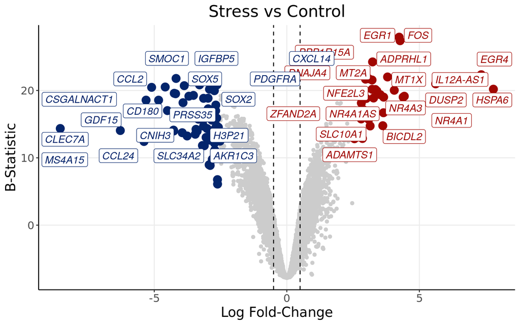

```r
upmarkers <- as.data.frame(DEGenes.uvss[DEGenes.uvss$logFC>2.5 & DEGenes.uvss$adj.P.Val<0.05,] )
downmarkers <- as.data.frame(DEGenes.uvss[DEGenes.uvss$logFC< -2.5 & DEGenes.uvss$adj.P.Val<0.05,] )

ggplot(data=DEGenes.uvss,
                 aes(x=logFC,
                     y=  B)) +
  geom_point(color="#CCCCCC")+ geom_vline(xintercept = -0.5, linetype="dashed")+geom_vline(xintercept = 0.5, linetype="dashed")+
  theme_bw() + ylab("B-Statistic")+xlab("Log Fold-Change")+
  theme(axis.line = element_line(colour = "black"),
        panel.grid.minor = element_blank(),
        panel.border = element_blank(),
        panel.background = element_blank()) +
  ggtitle("Stress vs Control")+
  theme(plot.title = element_text(hjust = 0.5), plot.subtitle = element_text(hjust = 0.5)) +
  geom_point(data=upmarkers, aes(x=logFC, y=  B), color="#A10702",size=4)+
  geom_point(data=downmarkers, aes(x=logFC, y=  B), color="#03256C",size=4)+
  geom_label_repel(upmarkers[1:ndegs,] , mapping=aes(label=row.names(upmarkers)[1:ndegs]),size=4,point.padding=-0.5, color="#A10702",max.overlaps = 20, fontface="italic")+
  geom_label_repel(downmarkers[1:ndegs,] , mapping=aes(label=row.names(downmarkers)[1:ndegs]),size=4,point.padding=-0.5, color="#03256C",max.overlaps = 20, fontface="italic")+
  theme(text=element_text(size=15,  family="Arial MS"))
```

## Stress vs Control (Volcano Plot with Gene Length)

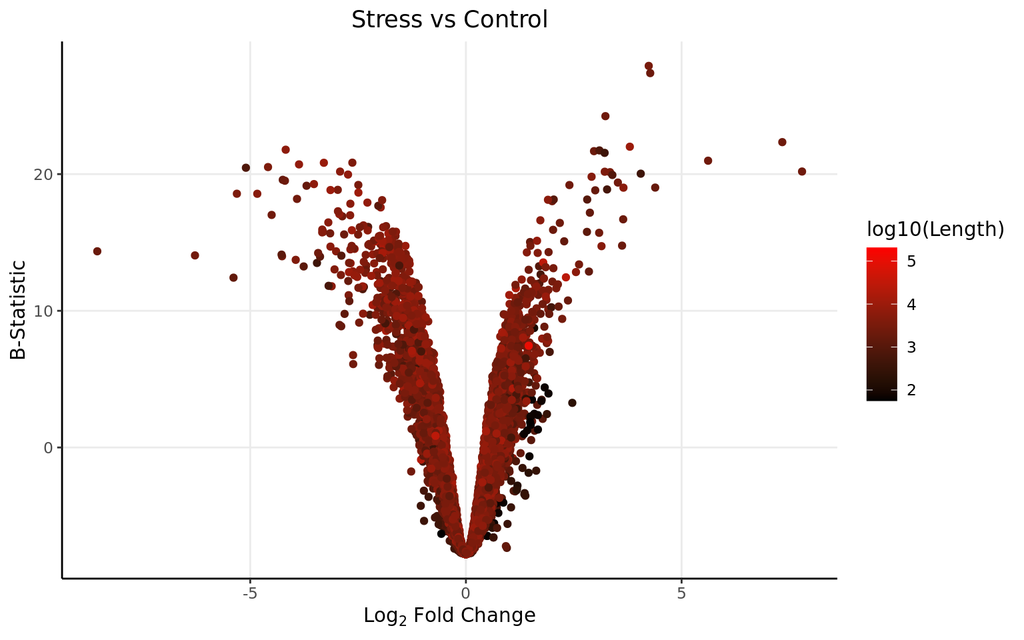

```r
DEGenes.uvss$Gene <- row.names(DEGenes.uvss)
colnames(genelength) <- c("Length","Gene")
DEGenes.uvss <- merge(DEGenes.uvss, genelength, by="Gene")

ggplot(data=DEGenes.uvss,
                 aes(x=logFC,
                     y=  B)) +
  geom_point(aes(color=log10(Length)))+
  theme_bw() +
  theme(axis.line = element_line(colour = "black"),
        panel.grid.minor = element_blank(),
        panel.border = element_blank(),
        panel.background = element_blank()) +
  ggtitle("Stress vs Control")+ xlab(expression(Log[2] ~ Fold ~ Change)) + ylab("B-Statistic") +
  theme(plot.title = element_text(hjust = 0.5))  +
  scale_colour_gradient(low = "black", high = "red")+ theme(text=element_text(family = "Quicksand"))
```

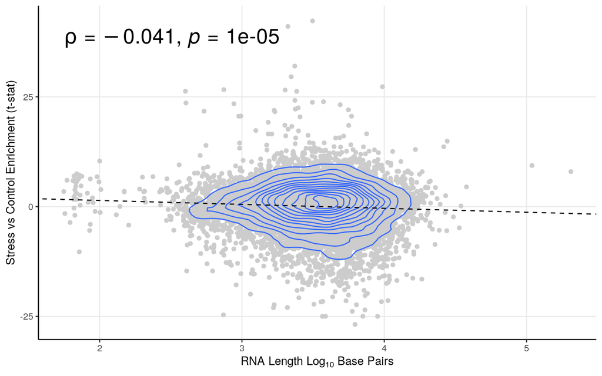

```r
smooth.SG <- lm(t~log10(Length), DEGenes.uvss)
liner.SG <- rstandard(smooth.SG)
DEGenes.uvss <-cbind(DEGenes.uvss, liner.SG)
colnames(DEGenes.uvss)[9] <- "Residuals"
row.names(DEGenes.uvss) <- DEGenes.uvss$Gene
linemarkers <- as.data.frame(DEGenes.uvss[abs(DEGenes.uvss$Residuals)>4,])

# Calculate the Spearman correlation coefficient
spearman_corr <- cor(DEGenes.uvss$t, log10(DEGenes.uvss$Length), method = "spearman")



ggplot(DEGenes.uvss, aes(y=t, x=log10(Length))) + geom_point(color="#CCCCCC", alpha=1) +   theme_bw()+ geom_density_2d()+
 ylab("Stress vs Control Enrichment (t-stat)") + xlab(expression(RNA ~ Length ~ Log[10] ~ Base ~ Pairs)) +
  theme(axis.line = element_line(colour = "black"),
        panel.grid.minor = element_blank(),
        panel.border = element_blank(),
        panel.background = element_blank()) +
  theme(plot.title = element_text(hjust = 0.5))  +
  geom_abline(slope=smooth.SG$coefficients[2], intercept = smooth.SG$coefficients[1], linetype = "dashed")+ stat_cor(method = "spearman", cor.coef.name = "rho",size=7)
```

## GSEA

Now that we have our genes of interest, it would also be interesting to see what are the **altered pathways** between enriched and depleted RNAs from the stress granules. Therefore, lets perform a *Gene Set Enrichment Analysis*

```r
#for all genes
DEGenes.uvss <- DEGenes.uvss[order(DEGenes.uvss[,4]),]
gseatool <- DEGenes.uvss[,4]
gseatool <- as.data.frame(gseatool)
colnames(gseatool)[1] <- "t"
gseatool[,2] <- DEGenes.uvss$Gene
colnames(gseatool)[2] <- "Symbol"
gseatool <- gseatool[,c(2,1)]

vectorranks <- gseatool$t
names(vectorranks) <- gseatool$Symbol


#to load our pathways
hallmarks.gs <- msigdbr(species = "Homo sapiens", collection =  "H")

hallmarks.gsets <- hallmarks.gs %>% split(x = .$gene_symbol, f = .$gs_name)

for (set in names(hallmarks.gsets)){
  hallmarks.gsets[[set]] <- toupper(hallmarks.gsets[[set]])
}

hallmarks.res <- fgsea(pathways = hallmarks.gsets,
                       stats = vectorranks)
```

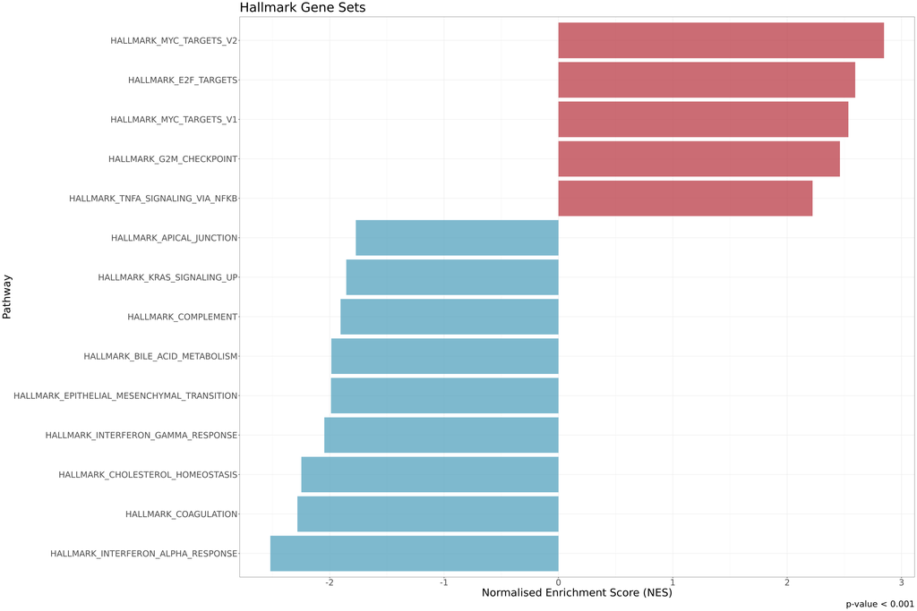

```r
hallmarks.res.tidy <- hallmarks.res %>%
  as_tibble() %>%
  arrange(desc(NES))

hallmarks.res.tidy %>%
  dplyr::select(-leadingEdge, -ES) %>%
  arrange(padj)

hallmark.sg.t <- hallmarks.res.tidy[,c(1,6)]
hallmark.sg.t <- as.data.frame(hallmark.sg.t)

#this small part is generic
thresh <- 0.001

#this one is no longer generic
data_to_plot <- hallmarks.res.tidy %>% filter(padj < thresh)

statvec <- c()
for (i in 1:nrow(data_to_plot)){
  if (data_to_plot[i,6] > 0){
    status <- "Upregulated"
  }
 else {
   status <- "Downregulated"
 }
statvec <- c(statvec, status)
}

data_to_plot$Status <- statvec

##-----HALMARK-----
gsea_plot_hall <- ggplot(data_to_plot, aes(reorder(pathway, NES), NES)) +
  geom_col(aes(fill= Status), alpha=0.75) + scale_fill_manual(values = c("#53A2BE","#BA3B46"), name = "Regulation Status", labels = c("Downregulated", "Upregulated"), breaks = c("Downregulated", "Upregulated")) +
  coord_flip() +
  labs(x="Pathway", y="Normalised Enrichment Score (NES)",
       title= "Hallmark Gene Sets",
       caption = paste0("p-value < ", thresh)) + theme(plot.title = element_text(hjust = 1)) +
  theme_bw() + theme(text=element_text(family = "Quicksand")) + theme(legend.position = "none")

gsea_plot_hall+
  theme(text=element_text(size=25,  family="Arial MS"))
```

## GSEA Length

Now that we have our genes of interest, it would also be interesting to see what are the **altered pathways** between enriched and depleted RNAs from the stress granules. Therefore, lets perform a *Gene Set Enrichment Analysis*

```r
#for all genes
DEGenes.uvss <- DEGenes.uvss[order(DEGenes.uvss[,8]),]
gseatool <- DEGenes.uvss[,8]
gseatool <- as.data.frame(gseatool)
colnames(gseatool)[1] <- "t"
gseatool[,2] <- DEGenes.uvss$Gene
colnames(gseatool)[2] <- "Symbol"
gseatool <- gseatool[,c(2,1)]


vectorranks <- log10(gseatool$t)
vectorranks <- scale(vectorranks)
names(vectorranks) <- gseatool$Symbol


#to load our pathways

##-----HALLMARK-----
hallmarks.gs <- msigdbr(species = "Homo sapiens", collection = "H")

hallmarks.gsets <- hallmarks.gs %>% split(x = .$gene_symbol, f = .$gs_name)

for (set in names(hallmarks.gsets)){
  hallmarks.gsets[[set]] <- toupper(hallmarks.gsets[[set]])
}

hallmarks.res <- fgsea(pathways = hallmarks.gsets,
                       stats = vectorranks)
```

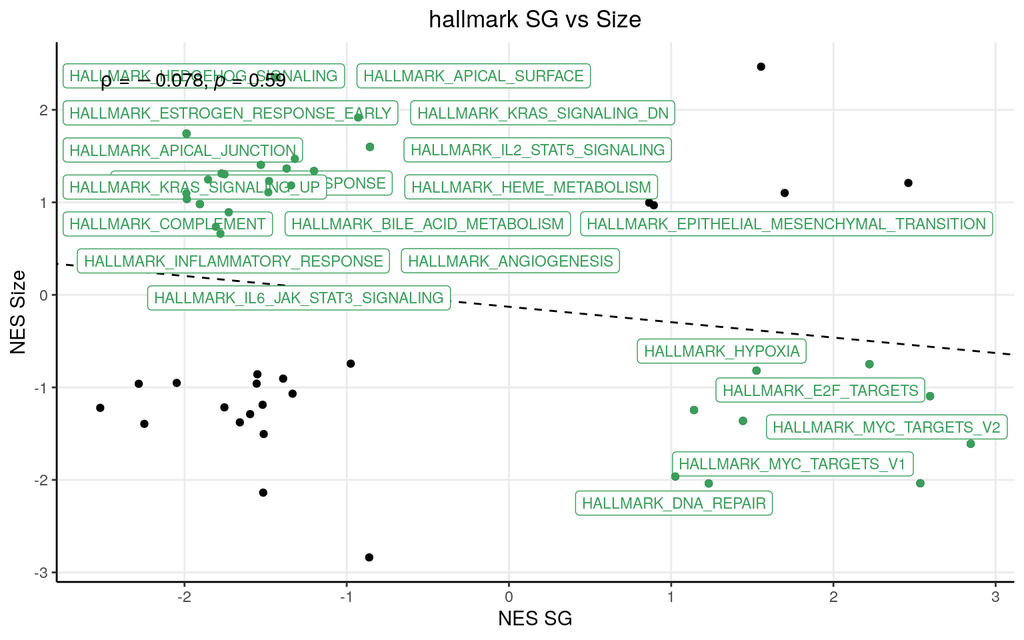

```r
hallmarks.res.tidy <- hallmarks.res %>%
  as_tibble() %>%
  arrange(desc(NES))

hallmarks.res.tidy %>%
  dplyr::select(-leadingEdge, -ES) %>%
  arrange(padj)

hallmark.size.t <- hallmarks.res.tidy[,c(1,6)]
hallmark.size.t <- as.data.frame(hallmark.size.t)

#HALLMARK
hallmark.scatter_ak <- merge(hallmark.sg.t, hallmark.size.t, by="pathway")
colnames(hallmark.scatter_ak) <- c("pathway", "sg", "size")
hallmark.scatter_ak <- na.omit(hallmark.scatter_ak)
res_hallmark <- lm(size ~ sg, hallmark.scatter_ak)

vip.pathways_ak <- as.data.frame(hallmark.scatter_ak[(hallmark.scatter_ak$sg/hallmark.scatter_ak$size)<0,] )



ggplot(hallmark.scatter_ak, aes(x=sg, y=size)) + geom_point(color="black", alpha=01) +   theme_bw()+
 xlab("NES SG") + ylab("NES Size") +
  theme(axis.line = element_line(colour = "black"),
        panel.grid.minor = element_blank(),
        panel.border = element_blank(),
        panel.background = element_blank()) + ggtitle("hallmark SG vs Size")+
  theme(plot.title = element_text(hjust = 0.5)) +
  geom_abline(slope=res_hallmark$coefficients[2], intercept = res_hallmark$coefficients[1], linetype = "dashed") +
  geom_label_repel(vip.pathways_ak[1:ndegs,] , mapping=aes(label=vip.pathways_ak$pathway[1:ndegs]),size=3,point.padding=-0.5, color="#399e5a",max.overlaps = 200)+
  geom_point(data=vip.pathways_ak, aes(x=sg, y= size), color="#399e5a") + stat_cor(method = "spearman", cor.coef.name = "rho")
```

# Interaction (SG)

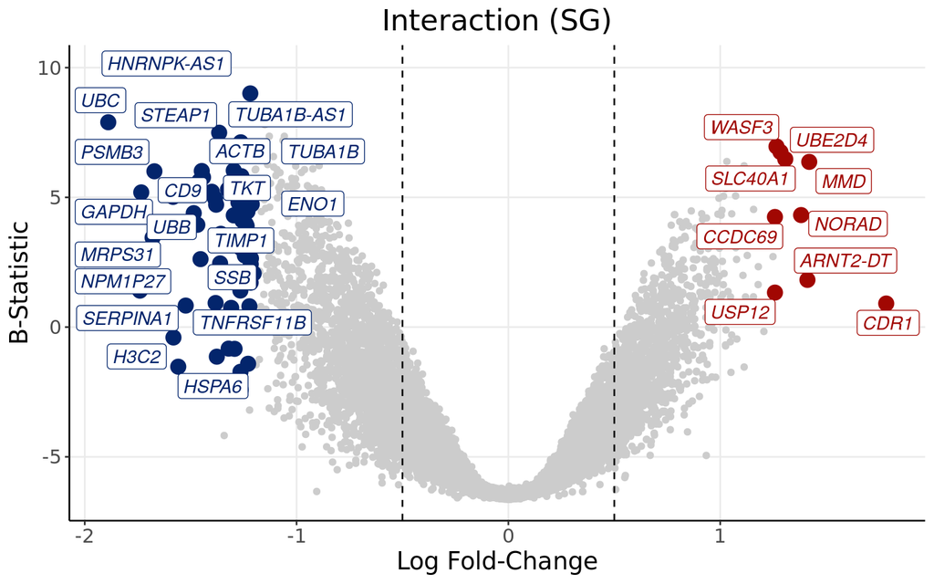

```r
upmarkers <- as.data.frame(DEGenes.int[DEGenes.int$logFC>1.25 & DEGenes.int$adj.P.Val<0.05,] )
downmarkers <- as.data.frame(DEGenes.int[DEGenes.int$logFC< -1.2 & DEGenes.int$adj.P.Val<0.05,] )


ggplot(data=DEGenes.int,
                 aes(x=logFC,
                     y=  B)) +
  geom_point(color="#CCCCCC")+ geom_vline(xintercept = -0.5, linetype="dashed")+geom_vline(xintercept = 0.5, linetype="dashed")+
  theme_bw() + ylab("B-Statistic")+xlab("Log Fold-Change")+
  theme(axis.line = element_line(colour = "black"),
        panel.grid.minor = element_blank(),
        panel.border = element_blank(),
        panel.background = element_blank()) +
  ggtitle("Interaction (SG)")+
  theme(plot.title = element_text(hjust = 0.5), plot.subtitle = element_text(hjust = 0.5)) +
  geom_point(data=upmarkers, aes(x=logFC, y=  B), color="#A10702",size=4)+
  geom_point(data=downmarkers, aes(x=logFC, y=  B), color="#03256C",size=4)+
  geom_label_repel(upmarkers[1:ndegs,] , mapping=aes(label=row.names(upmarkers)[1:ndegs]),size=4,point.padding=-0.5, color="#A10702",max.overlaps = 20, fontface="italic")+
  geom_label_repel(downmarkers[1:ndegs,] , mapping=aes(label=row.names(downmarkers)[1:ndegs]),size=4,point.padding=-0.5, color="#03256C",max.overlaps = 20, fontface="italic")+
  theme(text=element_text(size=15,  family="Arial MS"))
```

## Interaction (SG) (Volcano Plot with Gene Length)

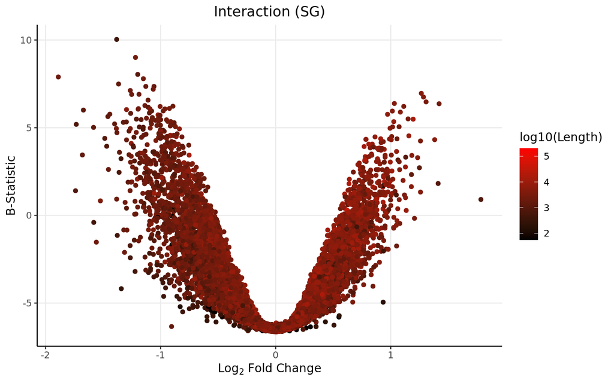

```r
DEGenes.int$Gene <- row.names(DEGenes.int)
colnames(genelength) <- c("Length","Gene")
DEGenes.int <- merge(DEGenes.int, genelength, by="Gene")

ggplot(data=DEGenes.int,
                 aes(x=logFC,
                     y=  B)) +
  geom_point(aes(color=log10(Length)))+
  theme_bw() +
  theme(axis.line = element_line(colour = "black"),
        panel.grid.minor = element_blank(),
        panel.border = element_blank(),
        panel.background = element_blank()) +
  ggtitle("Interaction (SG)")+ xlab(expression(Log[2] ~ Fold ~ Change)) + ylab("B-Statistic") +
  theme(plot.title = element_text(hjust = 0.5))  +
  scale_colour_gradient(low = "black", high = "red")+ theme(text=element_text(family = "Quicksand"))
```

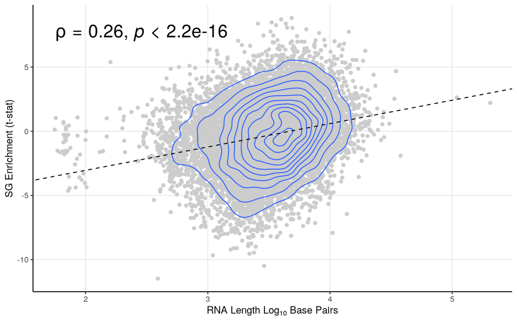

```r
smooth.SG <- lm(t~log10(Length), DEGenes.int)
liner.SG <- rstandard(smooth.SG)
DEGenes.int <-cbind(DEGenes.int, liner.SG)
colnames(DEGenes.int)[9] <- "Residuals"
row.names(DEGenes.int) <- DEGenes.int$Gene
linemarkers <- as.data.frame(DEGenes.int[abs(DEGenes.int$Residuals)>4,])

# Calculate the Spearman correlation coefficient
spearman_corr <- cor(DEGenes.int$t, log10(DEGenes.int$Length), method = "spearman")



ggplot(DEGenes.int, aes(y=t, x=log10(Length))) + geom_point(color="#CCCCCC", alpha=1) +   theme_bw()+ geom_density_2d()+
 ylab("SG Enrichment (t-stat)") + xlab(expression(RNA ~ Length ~ Log[10] ~ Base ~ Pairs)) +
  theme(axis.line = element_line(colour = "black"),
        panel.grid.minor = element_blank(),
        panel.border = element_blank(),
        panel.background = element_blank()) +
  theme(plot.title = element_text(hjust = 0.5))  +
  geom_abline(slope=smooth.SG$coefficients[2], intercept = smooth.SG$coefficients[1], linetype = "dashed")+ stat_cor(method = "spearman", cor.coef.name = "rho",size=7)
```

## GSEA

Now that we have our genes of interest, it would also be interesting to see what are the **altered pathways** between enriched and depleted RNAs from the stress granules. Therefore, lets perform a *Gene Set Enrichment Analysis*

```r
#for all genes
DEGenes.int <- DEGenes.int[order(DEGenes.int[,4]),]
gseatool <- DEGenes.int[,4]
gseatool <- as.data.frame(gseatool)
colnames(gseatool)[1] <- "t"
gseatool[,2] <- DEGenes.int$Gene
colnames(gseatool)[2] <- "Symbol"
gseatool <- gseatool[,c(2,1)]

vectorranks <- gseatool$t
names(vectorranks) <- gseatool$Symbol


#to load our pathways
hallmarks.gs <- msigdbr(species = "Homo sapiens", collection =  "H")

hallmarks.gsets <- hallmarks.gs %>% split(x = .$gene_symbol, f = .$gs_name)

for (set in names(hallmarks.gsets)){
  hallmarks.gsets[[set]] <- toupper(hallmarks.gsets[[set]])
}

hallmarks.res <- fgsea(pathways = hallmarks.gsets,
                       stats = vectorranks)
```

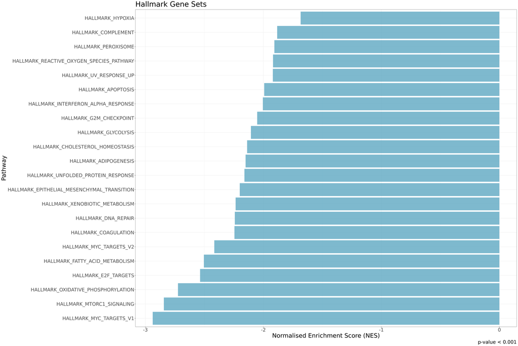

```r
hallmarks.res.tidy <- hallmarks.res %>%
  as_tibble() %>%
  arrange(desc(NES))

hallmarks.res.tidy %>%
  dplyr::select(-leadingEdge, -ES) %>%
  arrange(padj)

hallmark.sg.t <- hallmarks.res.tidy[,c(1,6)]
hallmark.sg.t <- as.data.frame(hallmark.sg.t)

#this small part is generic
thresh <- 0.001

#this one is no longer generic
data_to_plot <- hallmarks.res.tidy %>% filter(padj < thresh)

statvec <- c()
for (i in 1:nrow(data_to_plot)){
  if (data_to_plot[i,6] > 0){
    status <- "Upregulated"
  }
 else {
   status <- "Downregulated"
 }
statvec <- c(statvec, status)
}

data_to_plot$Status <- statvec

##-----HALMARK-----
gsea_plot_hall <- ggplot(data_to_plot, aes(reorder(pathway, NES), NES)) +
  geom_col(aes(fill= Status), alpha=0.75) + scale_fill_manual(values = c("#53A2BE","#BA3B46"), name = "Regulation Status", labels = c("Downregulated", "Upregulated"), breaks = c("Downregulated", "Upregulated")) +
  coord_flip() +
  labs(x="Pathway", y="Normalised Enrichment Score (NES)",
       title= "Hallmark Gene Sets",
       caption = paste0("p-value < ", thresh)) + theme(plot.title = element_text(hjust = 1)) +
  theme_bw() + theme(text=element_text(family = "Quicksand")) + theme(legend.position = "none")

gsea_plot_hall+
  theme(text=element_text(size=25,  family="Arial MS"))
```

## GSEA Length

Now that we have our genes of interest, it would also be interesting to see what are the **altered pathways** between enriched and depleted RNAs from the stress granules. Therefore, lets perform a *Gene Set Enrichment Analysis*

```r
#for all genes
DEGenes.int <- DEGenes.int[order(DEGenes.int[,8]),]
gseatool <- DEGenes.int[,8]
gseatool <- as.data.frame(gseatool)
colnames(gseatool)[1] <- "t"
gseatool[,2] <- DEGenes.int$Gene
colnames(gseatool)[2] <- "Symbol"
gseatool <- gseatool[,c(2,1)]


vectorranks <- log10(gseatool$t)
vectorranks <- scale(vectorranks)
names(vectorranks) <- gseatool$Symbol


#to load our pathways

##-----HALLMARK-----
hallmarks.gs <- msigdbr(species = "Homo sapiens", collection = "H")

hallmarks.gsets <- hallmarks.gs %>% split(x = .$gene_symbol, f = .$gs_name)

for (set in names(hallmarks.gsets)){
  hallmarks.gsets[[set]] <- toupper(hallmarks.gsets[[set]])
}

hallmarks.res <- fgsea(pathways = hallmarks.gsets,
                       stats = vectorranks)
```

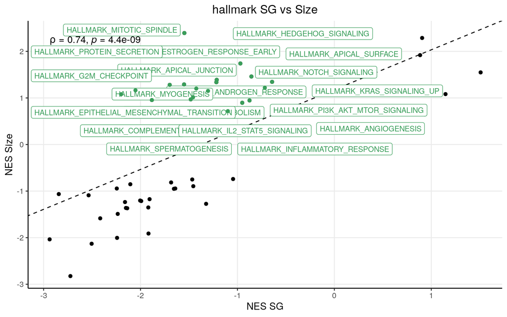

```r
hallmarks.res.tidy <- hallmarks.res %>%
  as_tibble() %>%
  arrange(desc(NES))

hallmarks.res.tidy %>%
  dplyr::select(-leadingEdge, -ES) %>%
  arrange(padj)

hallmark.size.t <- hallmarks.res.tidy[,c(1,6)]
hallmark.size.t <- as.data.frame(hallmark.size.t)

#HALLMARK
hallmark.scatter_ak <- merge(hallmark.sg.t, hallmark.size.t, by="pathway")
colnames(hallmark.scatter_ak) <- c("pathway", "sg", "size")
hallmark.scatter_ak <- na.omit(hallmark.scatter_ak)
res_hallmark <- lm(size ~ sg, hallmark.scatter_ak)

vip.pathways_ak <- as.data.frame(hallmark.scatter_ak[(hallmark.scatter_ak$sg/hallmark.scatter_ak$size)<0,] )



ggplot(hallmark.scatter_ak, aes(x=sg, y=size)) + geom_point(color="black", alpha=01) +   theme_bw()+
 xlab("NES SG") + ylab("NES Size") +
  theme(axis.line = element_line(colour = "black"),
        panel.grid.minor = element_blank(),
        panel.border = element_blank(),
        panel.background = element_blank()) + ggtitle("hallmark SG vs Size")+
  theme(plot.title = element_text(hjust = 0.5)) +
  geom_abline(slope=res_hallmark$coefficients[2], intercept = res_hallmark$coefficients[1], linetype = "dashed") +
  geom_label_repel(vip.pathways_ak[1:ndegs,] , mapping=aes(label=vip.pathways_ak$pathway[1:ndegs]),size=3,point.padding=-0.5, color="#399e5a",max.overlaps = 200)+
  geom_point(data=vip.pathways_ak, aes(x=sg, y= size), color="#399e5a") + stat_cor(method = "spearman", cor.coef.name = "rho")
```

# Correlation SGS vs SGU Enrichment

```r
sgs_t <- merge(stress_rnpt, unstress_t, by="Gene")
sgs_t <- merge(sgs_t, genelength, by="Gene")



smooth.SG <- lm(uns_t~(srnp_t), sgs_t)
liner.SG <- rstandard(smooth.SG)
sgs_t <-cbind(sgs_t, liner.SG)
colnames(sgs_t)[5] <- "Residuals"
row.names(sgs_t) <- sgs_t$Gene
linemarkers <- as.data.frame(sgs_t[(sgs_t$st)>20,])

cor.test(sgs_t$uns_t, (sgs_t$srnp_t), method="spearman")
```

```
##
##  Spearman's rank correlation rho
##
## data:  sgs_t$uns_t and (sgs_t$srnp_t)
## S = 9.7225e+10, p-value < 2.2e-16
## alternative hypothesis: true rho is not equal to 0
## sample estimates:
##       rho
## 0.6032333
```

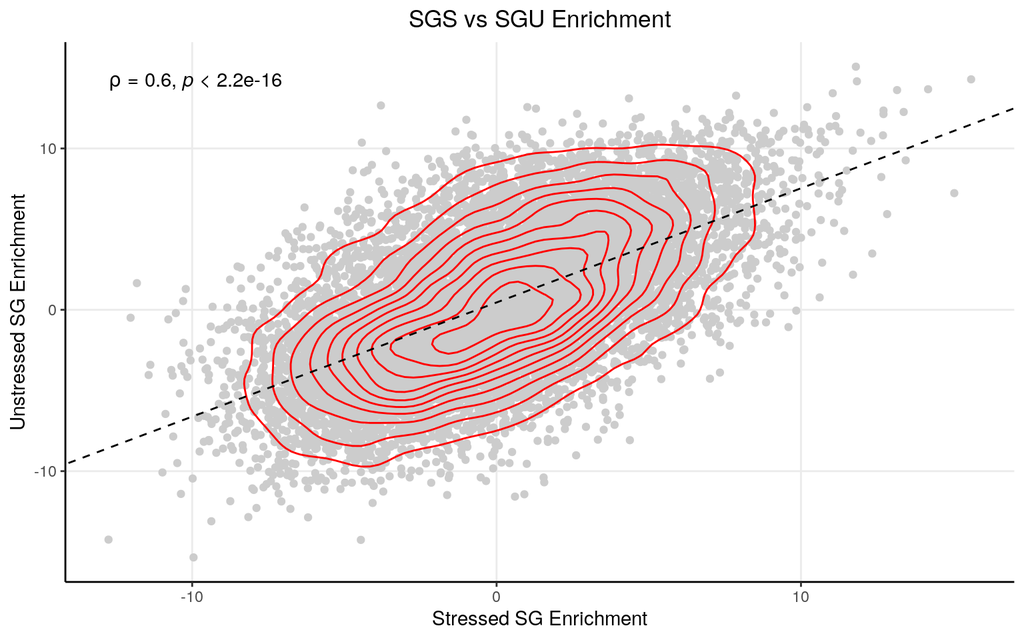

```r
ggplot(sgs_t, aes(y=uns_t, x=(srnp_t))) +geom_point(color="#CCCCCC", alpha=1) +   theme_bw()+
 xlab("Stressed SG Enrichment") + ylab("Unstressed SG Enrichment") + geom_density2d(colour="red")+ scale_colour_gradient(low="black", high="red")+
  theme(axis.line = element_line(colour = "black"),
        panel.grid.minor = element_blank(),
        panel.border = element_blank(),
        panel.background = element_blank()) + ggtitle("SGS vs SGU Enrichment")+stat_cor(method = "spearman", cor.coef.name = "rho")+
  theme(plot.title = element_text(hjust = 0.5))  +
  geom_abline(slope=smooth.SG$coefficients[2], intercept = smooth.SG$coefficients[1], linetype = "dashed") +
  geom_label_repel(linemarkers[1:ndegs,] , mapping=aes(label=rownames(linemarkers)[1:ndegs]),size=3,point.padding=-0.5, color="#399e5a",max.overlaps = 200)+
  geom_point(data=linemarkers, aes(x=srnp_t, y= uns_t), color="#399e5a")
```

# Alternative Methods (after centrifugation findings)

## Repetition of Interaction but with matrix centering

```r
#Lets create a dataframe with this information
centrifugation <- c(rep("Yes",6), rep("No",6))
stresstype <- c(rep("Ct",3), rep("Stressed",3),rep("Ct",3), rep("Stressed",3))

metadata <- data.frame(Centrifugation=centrifugation, Stress=stresstype)

mm <- model.matrix(~1+Centrifugation*Stress, metadata)
fitted <- lmFit(y, mm)



mm[,2] <- c(rep(0.5,6), rep(-0.5,6))
mm[,3] <- c(rep(-0.5,3), rep(0.5,3),rep(-0.5,3), rep(0.5,3))
mm[,4] <- mm[,2]*mm[,3]

head(coef(fitted))
```

```
##          (Intercept) CentrifugationYes StressStressed
## 7SK        13.159437        -1.9498188     0.63840161
## A1BG        2.590825        -0.7562226    -0.24365808
## A1BG-AS1    2.972066         0.2685564    -0.12095475
## A2M         3.722897         1.2595358    -0.85907951
## AAAS        5.207613         0.9866237    -0.05451936
## AACS        5.116202         0.9202286     0.15381764
##          CentrifugationYes:StressStressed
## 7SK                             0.3507537
## A1BG                            0.6729237
## A1BG-AS1                        0.5009668
## A2M                            -0.6732472
## AAAS                           -0.9610180
## AACS                           -0.5718529
```

```r
fitted <- lmFit(y$E, mm)

top.table <- topTable(tmp,4, sort.by = "logFC", n=Inf)
DEGenes_sg.pres <- top.table

ndegs=20
```

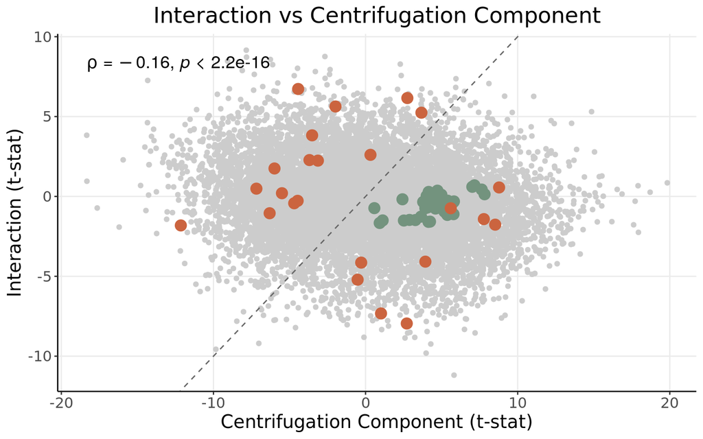

```r
tmp <- eBayes(fitted)

top_interact <- topTable(tmp, coef="CentrifugationYes:StressStressed", sort.by="logFC", n=Inf)
top_centri   <- topTable(tmp, coef="CentrifugationYes", sort.by="logFC", n=Inf)
top_stress   <- topTable(tmp, coef="StressStressed", sort.by="logFC", n=Inf)

interact_t <- data.frame(Gene=row.names(top_interact), interact_t=top_interact$t)
centri_t   <- data.frame(Gene=row.names(top_centri), centri_t=top_centri$t)
stress_t   <- data.frame(Gene=row.names(top_stress), stress_t=top_stress$t)

MitoGenes <- fread("~/MitoGenes.txt")[[1]]
NucGenes <- fread("~/rnalocate_mito_filt.csv")[[1]]

## ---- Interaction vs Centrifugation component ----

comp1_df <- merge(interact_t, centri_t, by="Gene")
row.names(comp1_df) <- comp1_df$Gene
MitoData_c1 <- comp1_df[comp1_df$Gene %in% MitoGenes, ]
NucData_c1  <- comp1_df[comp1_df$Gene %in% NucGenes, ]

spearman_c1 <- cor(comp1_df$interact_t, comp1_df$centri_t, method = "spearman")

(p_c1 <- ggplot(comp1_df, aes(x=centri_t, y=interact_t)) +
  geom_point(color="#CCCCCC") +
  geom_point(data=MitoData_c1, aes(x=centri_t, y=interact_t), color="#73937E", size=4) +
  geom_point(data=NucData_c1, aes(x=centri_t, y=interact_t), color="#CB643F", size=4) +
  geom_abline(slope=1, intercept=0, linetype="dashed", color="grey40") +
  theme_bw() + ylab("Interaction (t-stat)") + xlab("Centrifugation Component (t-stat)") +
  theme(axis.line = element_line(colour = "black"),
        panel.grid.minor = element_blank(),
        panel.border = element_blank(),
        panel.background = element_blank()) +
  ggtitle("Interaction vs Centrifugation Component") +
  theme(plot.title = element_text(hjust = 0.5)) +
  theme(text=element_text(size=15, family="Arial MS")) +
  stat_cor(method = "spearman", cor.coef.name = "rho", size=5))
```

```r
png("~/Projects/StressGranules/SGPAPER/Images/PNG/Tmat19_InteractionVsCentri.png", width = 7, height=6, units = "in", res=300)
p_c1
dev.off()
```

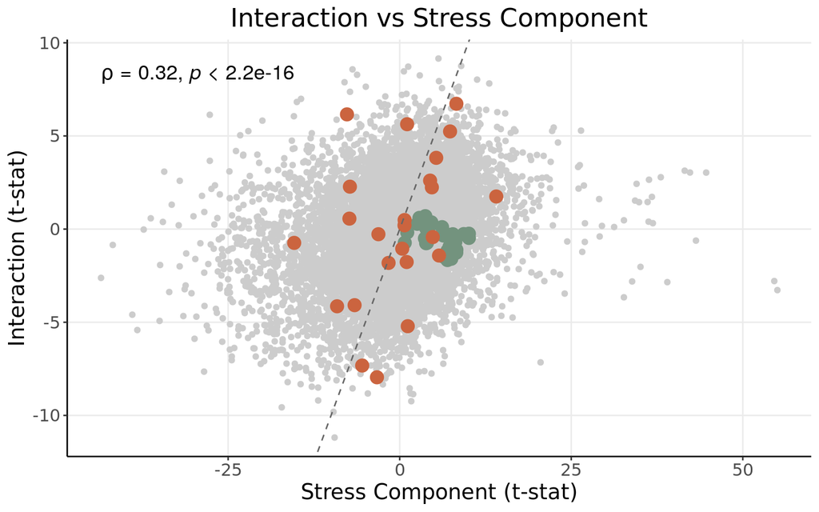

```r
## ---- Interaction vs Stress component ----

comp2_df <- merge(interact_t, stress_t, by="Gene")
row.names(comp2_df) <- comp2_df$Gene
MitoData_c2 <- comp2_df[comp2_df$Gene %in% MitoGenes, ]
NucData_c2  <- comp2_df[comp2_df$Gene %in% NucGenes, ]

spearman_c2 <- cor(comp2_df$interact_t, comp2_df$stress_t, method = "spearman")

(p_c2 <- ggplot(comp2_df, aes(x=stress_t, y=interact_t)) +
  geom_point(color="#CCCCCC") +
  geom_point(data=MitoData_c2, aes(x=stress_t, y=interact_t), color="#73937E", size=4) +
  geom_point(data=NucData_c2, aes(x=stress_t, y=interact_t), color="#CB643F", size=4) +
  geom_abline(slope=1, intercept=0, linetype="dashed", color="grey40") +
  theme_bw() + ylab("Interaction (t-stat)") + xlab("Stress Component (t-stat)") +
  theme(axis.line = element_line(colour = "black"),
        panel.grid.minor = element_blank(),
        panel.border = element_blank(),
        panel.background = element_blank()) +
  ggtitle("Interaction vs Stress Component") +
  theme(plot.title = element_text(hjust = 0.5)) +
  theme(text=element_text(size=15, family="Arial MS")) +
  stat_cor(method = "spearman", cor.coef.name = "rho", size=5))
```

```r
png("~/Projects/StressGranules/SGPAPER/Images/PNG/Tmat19_InteractionVsStress.png", width = 7, height=6, units = "in", res=300)
p_c2
dev.off()
```

### Volcano Plot

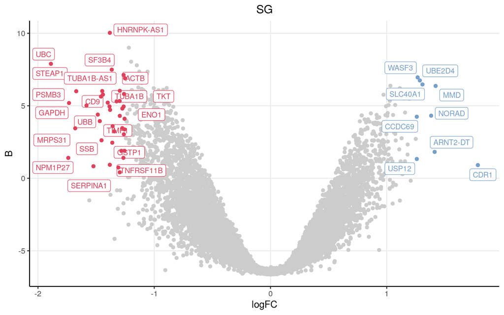

```r
write.table(x = DEGenes_sg.pres,
            file = "~/Projects/StressGranules/SGPAPER/RealSGs/RealMatheny2019.txt", sep="\t", col.names = TRUE, row.names = TRUE, quote=FALSE)


upmarkers <- as.data.frame(DEGenes_sg.pres[DEGenes_sg.pres$logFC>1.25 & DEGenes_sg.pres$B>0,] )
downmarkers <- as.data.frame(DEGenes_sg.pres[DEGenes_sg.pres$logFC< -1.25 & DEGenes_sg.pres$B>0,] )

ggplot(data=DEGenes_sg.pres,
                 aes(x=logFC,
                     y=  B)) +
  geom_point(color="#CCCCCC")+
  theme_bw() +
  theme(axis.line = element_line(colour = "black"),
        panel.grid.minor = element_blank(),
        panel.border = element_blank(),
        panel.background = element_blank()) +
  ggtitle("SG")+
  theme(plot.title = element_text(hjust = 0.5)) +
  geom_label_repel(upmarkers[1:ndegs,] , mapping=aes(label=row.names(upmarkers)[1:ndegs]),size=3,point.padding=-0.5, color="#769fca",max.overlaps = 20)+
  geom_label_repel(downmarkers[1:ndegs,] , mapping=aes(label=row.names(downmarkers)[1:ndegs]),size=3,point.padding=-0.5, color="#de425b",max.overlaps = 20)+
  geom_point(data=upmarkers, aes(x=logFC, y=  B), color="#769fca")+
  geom_point(data=downmarkers, aes(x=logFC, y=  B), color="#de425b")
```

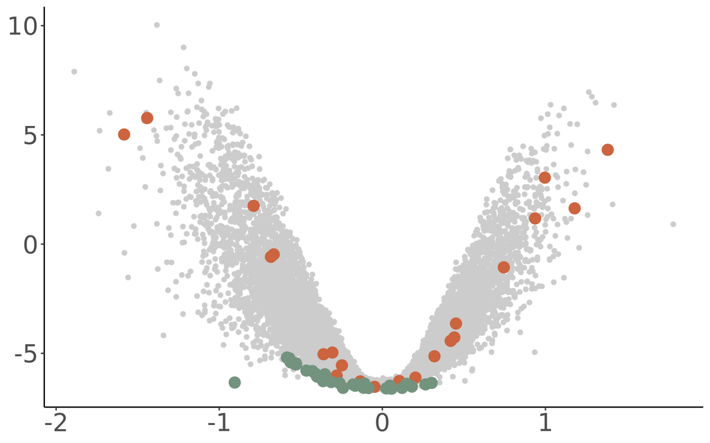

```r
DEGenes <- DEGenes_sg.pres
MitoGenes <- fread("~/MitoGenes.txt")[[1]]
MitoData <- DEGenes[rownames(DEGenes) %in% MitoGenes, ]
NucGenes <- fread("~/rnalocate_mito_filt.csv")[[1]]
NucData <- DEGenes[rownames(DEGenes) %in% NucGenes, ]
(m <- ggplot(data=DEGenes,
                 aes(x=logFC,
                     y=B)) +
  geom_point(color="#CCCCCC") +
  geom_point(data=NucData, aes(x=logFC, y=B), color="#CB643F", size=4) +
  geom_point(data=MitoData, aes(x=logFC, y=B), color="#73937E", size=4) +
  ylab("B-Statistic") +
  xlab(expression(Log[2]~"Fold-Change")) +
  theme(
    axis.line = element_line(colour = "black"),
    panel.grid.major = element_blank(),   # remove major gridlines
    panel.grid.minor = element_blank(),   # remove minor gridlines
    panel.border = element_blank(),
    panel.background = element_blank(),
    axis.title = element_blank()
  ) +
  theme(plot.title = element_text(hjust = 0.5), plot.subtitle = element_text(hjust = 0.5)) +
  theme(text=element_text(size=25, family="Arial MS")))
```

```r
png("~/Projects/StressGranules/SGPAPER/Images/PNG/TMat19Mito.png", width = 7, height=6, units = "in", res=300)
m
dev.off()
```

# MA Plot

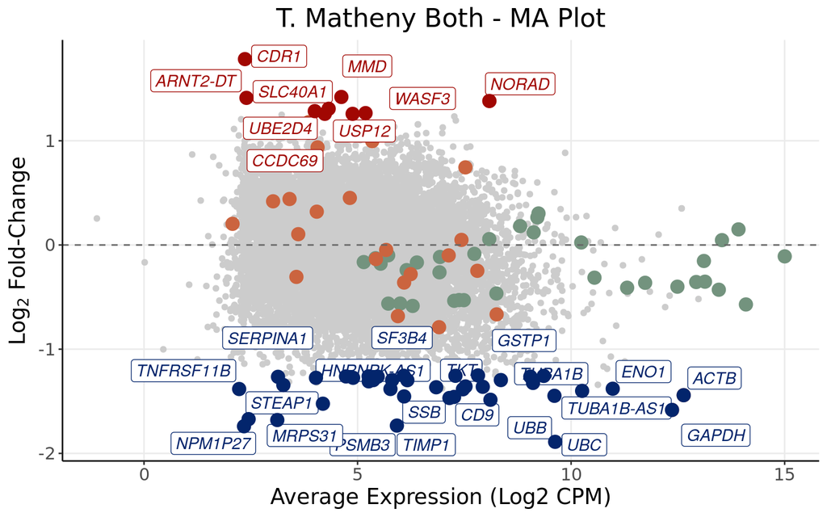

```r
# MA plot: mean expression (x) vs logFC (y), same highlighting scheme as the volcano

ggplot(data=DEGenes,
                 aes(x=AveExpr,
                     y=logFC)) +
  geom_point(color="#CCCCCC") +
  geom_point(data=MitoData, aes(x=AveExpr, y=logFC), color="#73937E", size=4) +
  geom_point(data=NucData, aes(x=AveExpr, y=logFC), color="#CB643F", size=4) +
  geom_hline(yintercept = 0, linetype="dashed", color="grey40") +
  theme_bw() + ylab(expression(Log[2]~"Fold-Change")) + xlab("Average Expression (Log2 CPM)") +
  theme(axis.line = element_line(colour = "black"),
        panel.grid.minor = element_blank(),
        panel.border = element_blank(),
        panel.background = element_blank()) +
  ggtitle("T. Matheny Both - MA Plot") +
  theme(plot.title = element_text(hjust = 0.5), plot.subtitle = element_text(hjust = 0.5)) +
  geom_label_repel(upmarkers[1:ndegs,], mapping=aes(x=AveExpr, y=logFC, label=row.names(upmarkers)[1:ndegs]), size=4, point.padding=-0.5, color="#A10702", max.overlaps=20, fontface="italic") +
  geom_label_repel(downmarkers[1:ndegs,], mapping=aes(x=AveExpr, y=logFC, label=row.names(downmarkers)[1:ndegs]), size=4, point.padding=-0.5, color="#03256C", max.overlaps=20, fontface="italic") +
  geom_point(data=upmarkers, aes(x=AveExpr, y=logFC), color="#A10702", size=4) +
  geom_point(data=downmarkers, aes(x=AveExpr, y=logFC), color="#03256C", size=4) +
  theme(text=element_text(size=15, family="Arial MS"))
```

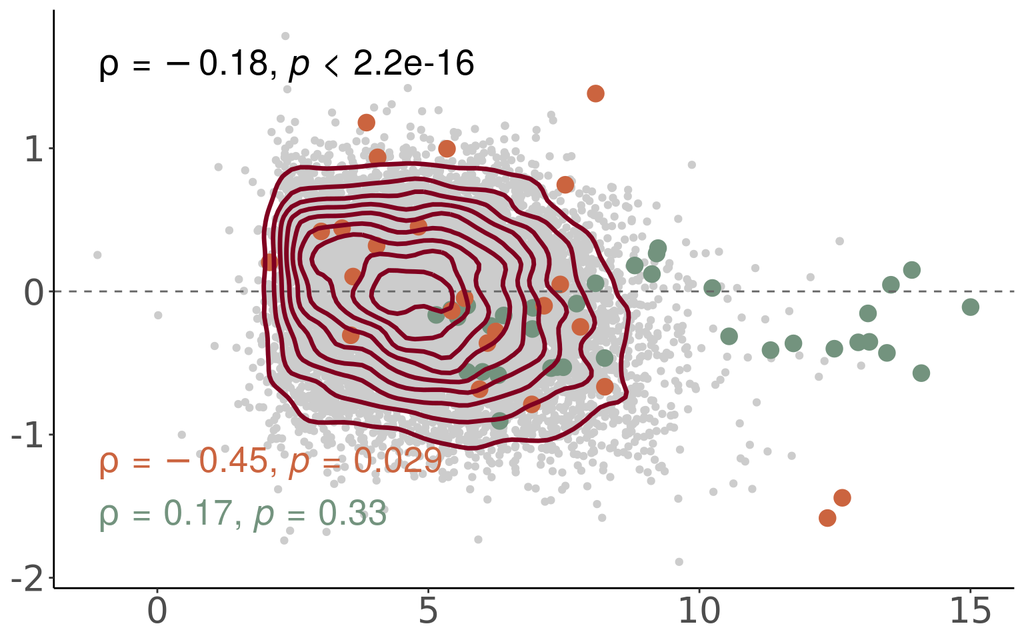

```r
# Publication-style version, stripped of axis titles, matching your "m" plot
(ma <- ggplot(data=DEGenes,
                 aes(x=AveExpr,
                     y=logFC)) +
  geom_point(color="#CCCCCC") +
  geom_point(data=MitoData, aes(x=AveExpr, y=logFC), color="#73937E", size=4) +
  geom_point(data=NucData, aes(x=AveExpr, y=logFC), color="#CB643F", size=4) +
  geom_hline(yintercept = 0, linetype="dashed", color="grey40") +
  ylab(expression(Log[2]~"Fold-Change")) +
  xlab("Average Expression (Log2 CPM)") + geom_density2d(color = "#800020", size = 1.2) + stat_cor(method = "spearman", cor.coef.name = "rho", size=7)+
  stat_cor(data = MitoData, aes(x=AveExpr, y=logFC), method = "spearman",
           cor.coef.name = "rho", size=7, color = "#73937E", label.y.npc = 0.1) +
  stat_cor(data = NucData, aes(x=AveExpr, y=logFC), method = "spearman",
           cor.coef.name = "rho", size=7, color = "#CB643F", label.y.npc = 0.2) +
  theme(
    axis.line = element_line(colour = "black"),
    panel.grid.major = element_blank(),
    panel.grid.minor = element_blank(),
    panel.border = element_blank(),
    panel.background = element_blank(),
    axis.title = element_blank()
  ) +
  theme(plot.title = element_text(hjust = 0.5), plot.subtitle = element_text(hjust = 0.5)) +
  theme(text=element_text(size=25, family="Arial MS")))
```

```r
png("~/Projects/StressGranules/SGPAPER/Images/PNG/Tmat19Mito_MA.png", width = 7, height=6, units = "in", res=300)
ma
dev.off()
```

## MA Plot

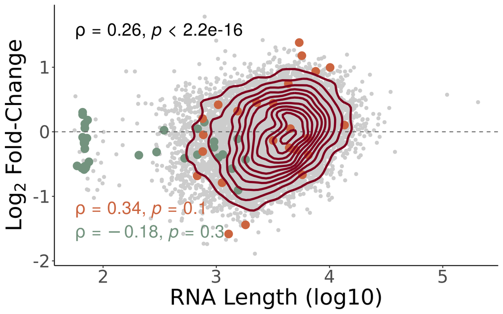

```r
MitoGenes <- fread("~/MitoGenes.txt")[[1]]

genelength <- read.csv("~/Projects/StressGranules/SG_Transcriptome/RP_Data_2021/TrimmedSamples/alignment_STAR/TranscriptLenght.txt", header=T)
genelength <- subset(genelength, Ensembl.Canonical==1)
genelength <- subset(genelength, Gene.name!="")
genelength <- genelength %>%
  group_by(Gene.name) %>%
  slice(which.max(Transcript.length..including.UTRs.and.CDS.)) %>%
  ungroup()
genelength <- genelength[,-c(2,3)]
colnames(genelength) <- c("Length", "Gene")

genelength$Cromo <- ifelse(genelength$Gene %in% MitoGenes, "Mito", "Other")

# Apply the length-based weight formula
genelength$S <- ifelse(
  genelength$Cromo == "Mito",
  (genelength$Length)^(1/3) * 3.23e-11 + 1.17e-9,   # Formula for mitochondrial RNAs
  (genelength$Length)^(1/3) * 6.09e-11 + 3.88e-10    # Formula for other RNAs
)
DEGenes$Gene <- row.names(DEGenes)
DEGenes <- merge(DEGenes, genelength, by="Gene")
MitoGenes <- fread("~/MitoGenes.txt")[[1]]
MitoData <- DEGenes[DEGenes$Gene %in% MitoGenes, ]
NucGenes <- fread("~/rnalocate_mito_filt.csv")[[1]]
NucData <- DEGenes[DEGenes$Gene %in% NucGenes, ]

# Publication-style version, stripped of axis titles, matching your "m" plot
(ma <- ggplot(data=DEGenes,
                 aes(x=log10(Length),
                     y=logFC)) +
  geom_point(color="#CCCCCC") +
  geom_point(data=MitoData, aes(x=log10(Length), y=logFC), color="#73937E", size=4) +
  geom_point(data=NucData, aes(x=log10(Length), y=logFC), color="#CB643F", size=4) +
  geom_hline(yintercept = 0, linetype="dashed", color="grey40") +
  ylab(expression(Log[2]~"Fold-Change")) +
  xlab("RNA Length (log10)") + geom_density2d(color = "#800020", size = 1.2) + stat_cor(method = "spearman", cor.coef.name = "rho", size=7)+
  stat_cor(data = MitoData, aes(x=log10(Length), y=logFC), method = "spearman",
           cor.coef.name = "rho", size=7, color = "#73937E", label.y.npc = 0.1) +
  stat_cor(data = NucData, aes(x=log10(Length), y=logFC), method = "spearman",
           cor.coef.name = "rho", size=7, color = "#CB643F", label.y.npc = 0.2) +
  theme(
    axis.line = element_line(colour = "black"),
    panel.grid.major = element_blank(),
    panel.grid.minor = element_blank(),
    panel.border = element_blank(),
    panel.background = element_blank()
  ) +
  theme(plot.title = element_text(hjust = 0.5), plot.subtitle = element_text(hjust = 0.5)) +
  theme(text=element_text(size=25, family="Arial MS")))
```

```r
png("~/Projects/StressGranules/SGPAPER/Images/PNG/TmatMito_MA_length.png", width = 7, height=6, units = "in", res=300)
ma
dev.off()
```

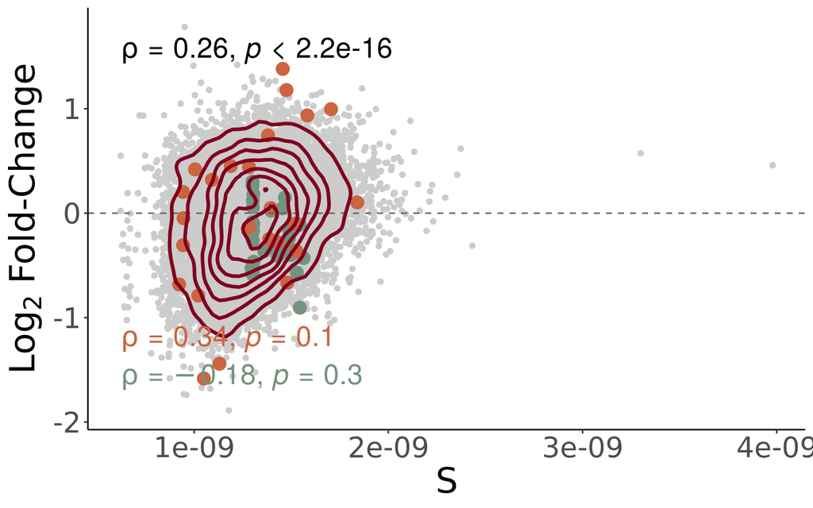

```r
# Publication-style version, stripped of axis titles, matching your "m" plot
(ma <- ggplot(data=DEGenes,
                 aes(x=(S),
                     y=logFC)) +
  geom_point(color="#CCCCCC") +
  geom_point(data=MitoData, aes(x=(S), y=logFC), color="#73937E", size=4) +
  geom_point(data=NucData, aes(x=(S), y=logFC), color="#CB643F", size=4) +
  geom_hline(yintercept = 0, linetype="dashed", color="grey40") +
  ylab(expression(Log[2]~"Fold-Change")) + geom_density2d(color = "#800020", size = 1.2) + stat_cor(method = "spearman", cor.coef.name = "rho", size=7)+
  stat_cor(data = MitoData, aes(x=S, y=logFC), method = "spearman",
           cor.coef.name = "rho", size=7, color = "#73937E", label.y.npc = 0.1) +
  stat_cor(data = NucData, aes(x=S, y=logFC), method = "spearman",
           cor.coef.name = "rho", size=7, color = "#CB643F", label.y.npc = 0.2) +
  xlab("S") +
  theme(
    axis.line = element_line(colour = "black"),
    panel.grid.major = element_blank(),
    panel.grid.minor = element_blank(),
    panel.border = element_blank(),
    panel.background = element_blank()
  ) +
  theme(plot.title = element_text(hjust = 0.5), plot.subtitle = element_text(hjust = 0.5)) +
  theme(text=element_text(size=25, family="Arial MS")))
```

```r
png("~/Projects/StressGranules/SGPAPER/Images/PNG/TmatMito_MA_S.png", width = 7, height=6, units = "in", res=300)
ma
dev.off()
```

### Volcano Plot (Length)

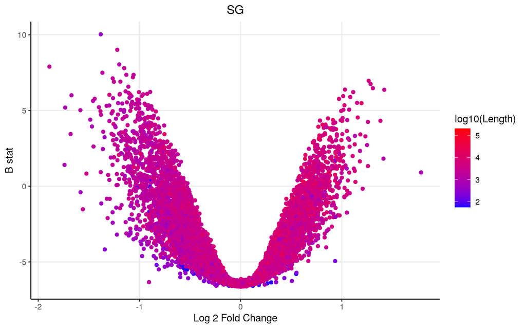

```r
DEGenes_sg.pres$Gene <- row.names(DEGenes_sg.pres)
DEGenes_sg.pres <- merge(DEGenes_sg.pres, genelength, by="Gene")

ggplot(data=DEGenes_sg.pres,
                 aes(x=logFC,
                     y=  B)) +
  geom_point(aes(color=log10(Length)))+
  theme_bw() +
  theme(axis.line = element_line(colour = "black"),
        panel.grid.minor = element_blank(),
        panel.border = element_blank(),
        panel.background = element_blank()) +
  ggtitle("SG")+ ylab("B stat")+xlab("Log 2 Fold Change") +
  theme(plot.title = element_text(hjust = 0.5))  +
  scale_colour_gradient(low = "blue", high = "red")
```

```r
smooth.SG <- lm(t~log10(Length), DEGenes_sg.pres)
liner.SG <- rstandard(smooth.SG)
DEGenes_sg.pres <-cbind(DEGenes_sg.pres, liner.SG)
colnames(DEGenes_sg.pres)[11] <- "Residuals"
row.names(DEGenes_sg.pres) <- DEGenes_sg.pres$Gene
linemarkers <- as.data.frame(DEGenes_sg.pres[abs(DEGenes_sg.pres$Residuals)>4,])

cor.test(DEGenes_sg.pres$t, log10(DEGenes_sg.pres$Length), method="spearman")
```

```
##
##  Spearman's rank correlation rho
##
## data:  DEGenes_sg.pres$t and log10(DEGenes_sg.pres$Length)
## S = 1.8246e+11, p-value < 2.2e-16
## alternative hypothesis: true rho is not equal to 0
## sample estimates:
##       rho
## 0.2554005
```

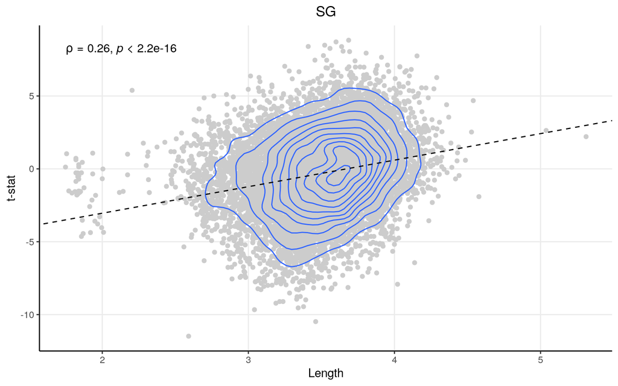

```r
ggplot(DEGenes_sg.pres, aes(y=t, x=log10(Length))) + geom_point(color="#CCCCCC", alpha=1) +   theme_bw()+ geom_density_2d()+
 ylab("t-stat") + xlab("Length") +
  theme(axis.line = element_line(colour = "black"),
        panel.grid.minor = element_blank(),
        panel.border = element_blank(),
        panel.background = element_blank()) + ggtitle("SG")+
  theme(plot.title = element_text(hjust = 0.5))  +
  geom_abline(slope=smooth.SG$coefficients[2], intercept = smooth.SG$coefficients[1], linetype = "dashed")+ stat_cor(method = "spearman", cor.coef.name = "rho")
```

## Violins

```r
library(data.table)
library(dplyr)
library(ggplot2)
library(rstatix)
expression.df <- y$E
centri_grp <- metadata$Centrifugation
stress_grp <- metadata$Stress
Condition  <- interaction(centri_grp, stress_grp, sep=".")

custom_palette <- c(
  "No.Ct"        = "#a2d1e6",
  "No.Stressed"  = "#769fca",
  "Yes.Ct"       = "#e88184",
  "Yes.Stressed" = "#de425b"
)

# ── 1. Gene sets already loaded earlier in the script (MitoGenes, NucGenes) ──
mito_genes_present <- MitoGenes[MitoGenes %in% rownames(expression.df)]
nuc_genes_present  <- NucGenes[NucGenes %in% rownames(expression.df)]
cat(length(mito_genes_present), "Mito genes found in expression matrix\n")
```

```
## 35 Mito genes found in expression matrix
```

```r
cat(length(nuc_genes_present), "Nuc genes found in expression matrix\n")
```

```
## 24 Nuc genes found in expression matrix
```

```r
# ── 2. Rank all genes per sample (1 = least expressed) ───────────────────────
rank_matrix <- apply(expression.df, 2, function(x) rank(x, ties.method = "average"))
rank_matrix <- as.data.frame(rank_matrix)

# ── 3. Compute a rank-sum score per sample, one gene set at a time ───────────
compute_score <- function(genes, rank_matrix, n_total) {
  colSums(rank_matrix[genes, , drop = FALSE]) / n_total
}

mito_score <- compute_score(mito_genes_present, rank_matrix, nrow(expression.df))
nuc_score  <- compute_score(nuc_genes_present, rank_matrix, nrow(expression.df))

# ── 4. Assemble plot dataframe, long format across both gene sets ────────────
score_df <- rbind(
  data.frame(Sample = colnames(expression.df), Score = as.numeric(mito_score),
             CentriGrp = centri_grp, StressGrp = stress_grp,
             Condition = Condition, GeneSet = "Mito"),
  data.frame(Sample = colnames(expression.df), Score = as.numeric(nuc_score),
             CentriGrp = centri_grp, StressGrp = stress_grp,
             Condition = Condition, GeneSet = "Nuc")
)

# ── 5. Statistics per gene set: two-way ANOVA (Centrifugation*Stress), interaction term ──
stat_labels <- score_df %>%
  group_by(GeneSet) %>%
  group_modify(~{
    aov_res  <- aov(Score ~ CentriGrp * StressGrp, data = .x)
    aov_tidy <- summary(aov_res)

    # The interaction term is the third row of the ANOVA table
    p_raw  <- aov_tidy[[1]][["Pr(>F)"]][3]
    p_adj  <- p.adjust(p_raw, method = "BH")

    ss_interact <- aov_tidy[[1]][["Sum Sq"]][3]
    ss_total    <- sum(aov_tidy[[1]][["Sum Sq"]])
    eta_sq      <- ss_interact / ss_total
    cohens_f    <- sqrt(eta_sq / (1 - eta_sq))

    data.frame(
      label = paste0("Interaction Cohen's f = ", round(cohens_f, 3),
                      "\nadj. p = ", formatC(p_adj, format = "e", digits = 2))
    )
  })

# ── 6. Plot ───────────────────────────────────────────────────────────────────
vilsigplot <- ggplot(score_df, aes(x = Condition, y = Score, fill = Condition)) +
  geom_violin(colour = "black", alpha = 0.6, trim = FALSE) +
  geom_point(
    position = position_jitter(width = 0.1),
    alpha    = 0.7,
    size     = 1.5
  ) +
  stat_summary(fun = mean,   geom = "point", shape = 18,
               size = 3, colour = "black") +
  stat_summary(fun = median, geom = "point", shape = 17,
               size = 3, colour = "black") +
  geom_text(
    data  = stat_labels,
    aes(x = -Inf, y = Inf, label = label),
    hjust = -0.05, vjust = 1.2,
    size  = 4, fontface = "bold", lineheight = 1.1,
    inherit.aes = FALSE
  ) +
  facet_wrap(~GeneSet, scales = "free_y") +
  scale_fill_manual(values = custom_palette) +
  labs(
    x     = "Centrifugation : Stress",
    y     = "Signature Score (Rank Sum)",
    title = "Mitochondrial vs Nuclear-Localized Gene Scores"
  ) +
  theme_bw() +
  theme(
    plot.title      = element_text(hjust = 0.5, size = 14, face = "bold"),
    axis.text.x     = element_text(size = 12, angle=20, hjust=1),
    strip.text      = element_text(size = 12, face = "bold"),
    legend.position = "none"
  )

png("~/Projects/StressGranules/SGPAPER/Images/PNG/Tmat19_MitoSigs.png", width = 14, height=6, units = "in", res=300)
vilsigplot
dev.off()
```

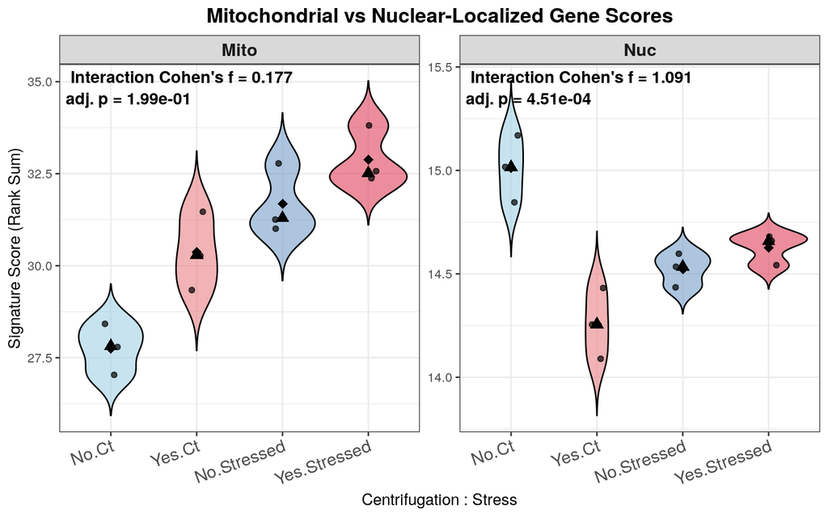

```r
vilsigplot
```

### GSEA

```r
#for all genes
DEGenes_sg.pres <- DEGenes_sg.pres[order(DEGenes_sg.pres[,4]),]
gseatool <- DEGenes_sg.pres[,4]
gseatool <- as.data.frame(gseatool)
colnames(gseatool)[1] <- "t"
gseatool[,2] <- DEGenes_sg.pres$Gene
colnames(gseatool)[2] <- "Symbol"
gseatool <- gseatool[,c(2,1)]

vectorranks <- gseatool$t
names(vectorranks) <- gseatool$Symbol


#to load our pathways
hallmarks.gs <- msigdbr(species = "Homo sapiens", collection =  "H")

hallmarks.gsets <- hallmarks.gs %>% split(x = .$gene_symbol, f = .$gs_name)

for (set in names(hallmarks.gsets)){
  hallmarks.gsets[[set]] <- toupper(hallmarks.gsets[[set]])
}

hallmarks.res <- fgsea(pathways = hallmarks.gsets,
                       stats = vectorranks)
```

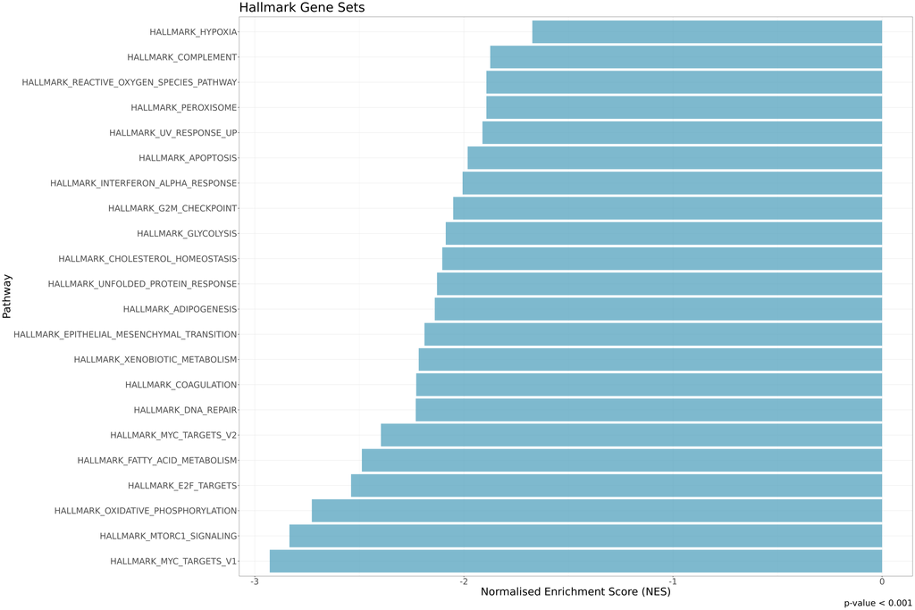

```r
hallmarks.res.tidy <- hallmarks.res %>%
  as_tibble() %>%
  arrange(desc(NES))

hallmarks.res.tidy %>%
  dplyr::select(-leadingEdge, -ES) %>%
  arrange(padj)

hallmark.sg.t <- hallmarks.res.tidy[,c(1,6)]
hallmark.sg.t <- as.data.frame(hallmark.sg.t)

#this small part is generic
thresh <- 0.001

#this one is no longer generic
data_to_plot <- hallmarks.res.tidy %>% filter(padj < thresh)

statvec <- c()
for (i in 1:nrow(data_to_plot)){
  if (data_to_plot[i,6] > 0){
    status <- "Upregulated"
  }
 else {
   status <- "Downregulated"
 }
statvec <- c(statvec, status)
}

data_to_plot$Status <- statvec

##-----HALMARK-----
gsea_plot_hall <- ggplot(data_to_plot, aes(reorder(pathway, NES), NES)) +
  geom_col(aes(fill= Status), alpha=0.75) + scale_fill_manual(values = c("#53A2BE","#BA3B46"), name = "Regulation Status", labels = c("Downregulated", "Upregulated"), breaks = c("Downregulated", "Upregulated")) +
  coord_flip() +
  labs(x="Pathway", y="Normalised Enrichment Score (NES)",
       title= "Hallmark Gene Sets",
       caption = paste0("p-value < ", thresh)) + theme(plot.title = element_text(hjust = 1)) +
  theme_bw() + theme(text=element_text(family = "Quicksand")) + theme(legend.position = "none")

gsea_plot_hall+
  theme(text=element_text(size=25,  family="Arial MS"))
```

### For Mito

```r
# --- Rank genes by t-statistic as usual ---
DEGenes_sg.pres <- DEGenes_sg.pres[order(DEGenes_sg.pres[,4]),]
gseatool <- DEGenes_sg.pres[,4]
gseatool <- as.data.frame(gseatool)
colnames(gseatool)[1] <- "t"
gseatool[,2] <- row.names(DEGenes_sg.pres)
colnames(gseatool)[2] <- "Symbol"
gseatool <- gseatool[,c(2,1)]
vectorranks <- gseatool$t
names(vectorranks) <- gseatool$Symbol

# --- Define MitoGenes as a custom gene set ---
MitoGenes <- fread("~/MitoGenes.txt")[[1]]
custom.gsets <- list(MitoGenes = toupper(MitoGenes))

# --- Run fgsea ---
mito.res <- fgsea(pathways = custom.gsets,
                  stats = vectorranks)
```

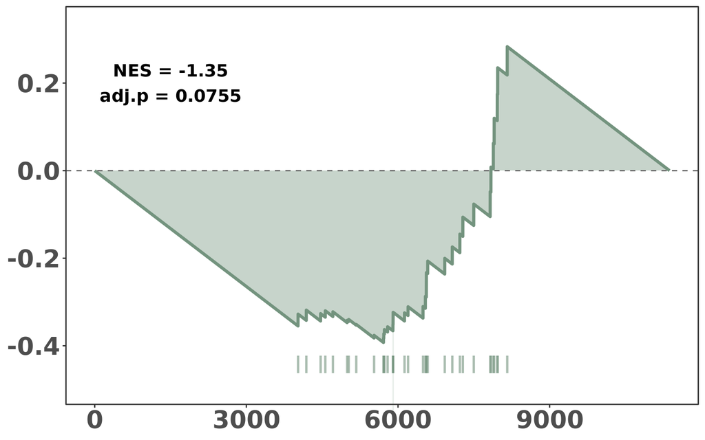

```r
mito.plot.base <- plotEnrichment(custom.gsets[["MitoGenes"]], vectorranks)
curve.data <- mito.plot.base$data

# --- key fix: match the curve's internal descending order ---
ord <- order(vectorranks, decreasing = TRUE)
ranked.names <- names(vectorranks)[ord]
gene.positions <- which(ranked.names %in% custom.gsets[["MitoGenes"]])

rug.top    <- min(curve.data$y) - 0.03
rug.bottom <- rug.top - 0.04

y.min <- rug.bottom - 0.03
y.max <- max(curve.data$y) + 0.05

(mito.plot <- ggplot(curve.data, aes(x = x, y = y)) +
  geom_area(fill = "#73937E", alpha = 0.4) +
  geom_line(color = "#73937E", linewidth = 1.2) +
  geom_hline(yintercept = 0, linetype = "dashed", color = "grey40") +
  geom_segment(data = data.frame(x = gene.positions),
               aes(x = x, xend = x, y = rug.top, yend = rug.bottom),
               color = "#73937E", alpha = 0.6, linewidth = 0.9,
               inherit.aes = FALSE) +
  annotate("text", x = 1500, y = 0.2,
           label = paste0("NES = ", round(mito.res$NES, 2),
                          "\nadj.p = ", round(mito.res$padj, 4)),
           size = 5, family = "Arial MS", fontface = "bold") +
  coord_cartesian(ylim = c(y.min, y.max), clip = "off") +
  theme_bw() +
  theme(text = element_text(size = 25, family = "Arial MS"),
        plot.title = element_text(hjust = 0.5, face = "bold"),
        axis.title = element_blank(),
        axis.text = element_text(face = "bold"),
        panel.grid.minor = element_blank(),
        panel.grid.major = element_blank()))
```

```r
png("~/Projects/StressGranules/SGPAPER/Images/PNG/MitoGSEA_TMat19.png", width=7, height=6, units="in", res=300)
mito.plot
dev.off()
```

The results are very similar with and without centering.

## SG as a Variable (for variance % calc)

```r
#Lets create a dataframe with this information
centrifugation <- c(rep("Yes",6), rep("No",6))
stresstype <- c(rep("Ct",3), rep("Stressed",3),rep("Ct",3), rep("Stressed",3))
sgpres <- c(rep("No",3), rep("Yes",3), rep("No",6))

metadata <- data.frame(Centrifugation=centrifugation, Stress=stresstype, SG=sgpres)

mm <- model.matrix(~0+Centrifugation+Stress+SG, metadata)
fitted <- lmFit(y, mm)

head(coef(fitted))
```

```
##          CentrifugationNo CentrifugationYes StressStressed      SGYes
## 7SK             13.159437         11.209618     0.63840161  0.3507537
## A1BG             2.590825          1.834602    -0.24365808  0.6729237
## A1BG-AS1         2.972066          3.240622    -0.12095475  0.5009668
## A2M              3.722897          4.982433    -0.85907951 -0.6732472
## AAAS             5.207613          6.194237    -0.05451936 -0.9610180
## AACS             5.116202          6.036430     0.15381764 -0.5718529
```

```r
fitted <- lmFit(y$E, mm)

top.table <- topTable(tmp,4, sort.by = "logFC", n=Inf)
DEGenes_sg.pres <- top.table

ndegs=20
```

```r
get_variance_explained_manual <- function(mat, metadata, variables) {
  # mat: genes x samples (rows = genes, cols = samples)
  # metadata: dataframe of sample annotations
  # variables: character vector of column names in metadata

  message("Calculating variance explained per gene...")

  # Ensure sample ordering matches
  stopifnot(ncol(mat) == nrow(metadata))

  results <- lapply(variables, function(var) {
    message("Processing ", var, "...")
    sapply(1:nrow(mat), function(i) {
      y <- as.numeric(mat[i, ])
      df <- data.frame(y = y, x = metadata[[var]])
      # handle categorical or numeric
      model <- lm(y ~ x, data = df)
      summary(model)$r.squared
    })
  })

  names(results) <- variables
  varMat <- as.data.frame(results)
  rownames(varMat) <- rownames(mat)
  return(varMat)
}
plot_variance_explained_density <- function(varMat, variables, colours, scale = "log") {
  df_plot <- reshape2::melt(varMat, variable.name = "Variable", value.name = "VarianceExplained")

  # Convert to percentage variance explained
  df_plot$VarianceExplained <- df_plot$VarianceExplained * 100

  # Convert input colours to pastel and name them to ensure correct mapping
  pastel_colours <- colorspace::lighten(colours, amount = 0.5)
  names(pastel_colours) <- variables

  # Build x scale based on argument
  x_scale <- if (scale == "log") {
    scale_x_log10(
      name = "% variance explained",
      breaks = c(0.001, 0.01, 0.1, 1, 10, 100),
      labels = c("0.001", "0.01", "0.1", "1", "10", "100")
    )
  } else if (scale == "linear") {
    scale_x_continuous(
      name = "% variance explained",
      breaks = c(0, 20, 40, 60, 80, 100),
      labels = c("0", "20", "40", "60", "80", "100"),
      limits = c(0, 100)
    )
  } else {
    stop("Invalid scale argument. Use 'log' or 'linear'.")
  }

  ggplot(df_plot, aes(x = VarianceExplained, color = Variable)) +
    geom_density(size = 1.2, adjust = 1.2) +
    x_scale +
    ylab("Density") +
    theme_bw(base_size = 16) +
    theme(
      plot.title = element_text(hjust = 0.5, size = 20),
      legend.title = element_text(size = 14),
      legend.text = element_text(size = 12),
      panel.grid.minor = element_blank(),
      panel.grid.major = element_blank()
    )  +
    scale_color_manual(values = pastel_colours)
}
#Example Usage
   #expression is your normalised expression table, with genes as rows and samples as coloumns (most likely y$E if you used voom)
   #metadata is your metadata frame where each column is a variable, and each row a sample. Must be in the same order as expression
   #variables must be a vector of the variables (columns in metadata) that you want to test. So something like  c("Centrifugation", "Stress", "SG")
   #colours must be a vector of the colours you want to use. Must be the same number as the variables. So something like c("#229954", "#EC7063", "blue")
varMat <- get_variance_explained_manual(y$E, metadata, colnames(metadata))
```

```
## Calculating variance explained per gene...
```

```
## Processing Centrifugation...
```

```
## Processing Stress...
```

```
## Processing SG...
```

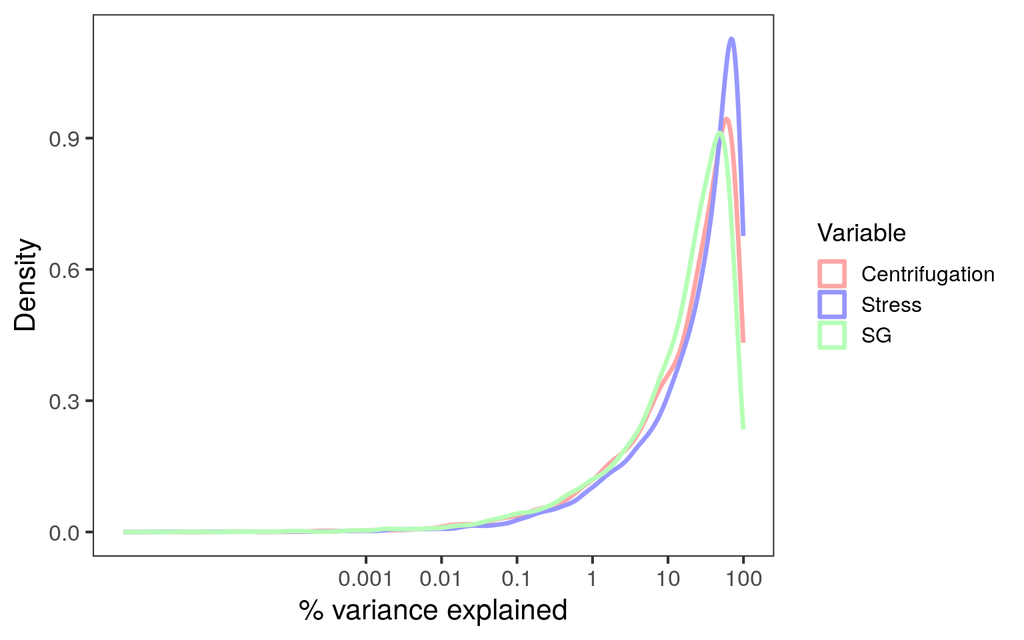

```r
# Log scale (default — no need to specify)
p <- plot_variance_explained_density(varMat, colnames(metadata), c("red", "blue", "green"))
print(p)
```

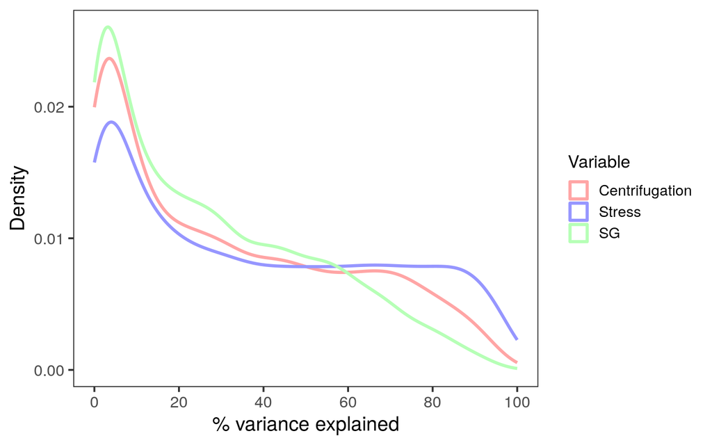

```r
# Linear scale
p <- plot_variance_explained_density(varMat, colnames(metadata), c("red", "blue", "green"), scale = "linear")
print(p)
```

```r
png("~/Projects/StressGranules/SGPAPER/Images/PNG/SupFigure4.png", width = 10, height=6, units = "in", res=300)
p
dev.off()
```

[^1]: Disease Transcriptomics Group, Gulbenkian Institute of Molecular Medicine